# Koodikirja, ESS 2023 - Suomen aineisto suomeksi

## **D13_1**: Keiden terveydenhoidon ammattilaisten kanssa olet keskustellut terveydestäsi kahdentoista viime kuukauden aikana? Yleislääkäri.

| Luokka | n | % | % vastanneista |
| --- | --- | --- | --- |
| Ei mainittu | 540 | 34.5% | 34.5% |
| Mainittu | 1023 | 65.5% | 65.5% |

## **D13_2**: Keiden terveydenhoidon ammattilaisten kanssa olet keskustellut terveydestäsi kahdentoista viime kuukauden aikana? Erikoislääkäri (ei hammaslääkäri).

| Luokka | n | % | % vastanneista |
| --- | --- | --- | --- |
| Ei mainittu | 807 | 51.6% | 51.6% |
| Mainittu | 756 | 48.4% | 48.4% |

## **D13_3**: Keiden terveydenhoidon ammattilaisten kanssa olet keskustellut terveydestäsi kahdentoista viime kuukauden aikana? Ei kukaan näistä.

| Luokka | n | % | % vastanneista |
| --- | --- | --- | --- |
| Ei mainittu | 1300 | 83.2% | 83.2% |
| Mainittu | 263 | 16.8% | 16.8% |

## **D13_4**: Keiden terveydenhoidon ammattilaisten kanssa olet keskustellut terveydestäsi kahdentoista viime kuukauden aikana? Ei halua vastata.

| Luokka | n | % | % vastanneista |
| --- | --- | --- | --- |
| Ei mainittu | 1563 | 100.0% | 100.0% |

## **D13_5**: Keiden terveydenhoidon ammattilaisten kanssa olet keskustellut terveydestäsi kahdentoista viime kuukauden aikana? EOS.

| Luokka | n | % | % vastanneista |
| --- | --- | --- | --- |
| Ei mainittu | 1563 | 100.0% | 100.0% |

## **D13_6**: Keiden terveydenhoidon ammattilaisten kanssa olet keskustellut terveydestäsi kahdentoista viime kuukauden aikana? Ei vastausta.

| Luokka | n | % | % vastanneista |
| --- | --- | --- | --- |
| Ei mainittu | 1563 | 100.0% | 100.0% |

## **D14**: Onko sinulle kahdentoista viime kuukauden aikana käynyt niin, ettet ole päässyt lääkärille tai tarvitsemaasi hoitoon?

| Luokka | n | % | % vastanneista |
| --- | --- | --- | --- |
| Kyllä | 333 | 21.3% | 21.3% |
| Ei | 1227 | 78.5% | 78.7% |
| NA | 3 | 0.2% | - |

## **D15_1**: Miksi et päässyt lääkärille tai tarvitsemaasi hoitoon? Ei ollut varaa.

| Luokka | n | % | % vastanneista |
| --- | --- | --- | --- |
| Ei mainittu | 1536 | 98.3% | 98.3% |
| Mainittu | 27 | 1.7% | 1.7% |

## **D15_2**: Miksi et päässyt lääkärille tai tarvitsemaasi hoitoon? Ei voinut olla töistä pois.

| Luokka | n | % | % vastanneista |
| --- | --- | --- | --- |
| Ei mainittu | 1537 | 98.3% | 98.3% |
| Mainittu | 26 | 1.7% | 1.7% |

## **D15_3**: Miksi et päässyt lääkärille tai tarvitsemaasi hoitoon? Oli muita esteitä.

| Luokka | n | % | % vastanneista |
| --- | --- | --- | --- |
| Ei mainittu | 1547 | 99.0% | 99.0% |
| Mainittu | 16 | 1.0% | 1.0% |

## **D15_4**: Miksi et päässyt lääkärille tai tarvitsemaasi hoitoon? Tarvittua hoitoa ei ollut saatavana kotipaikkakunnalla eikä sen läheisyydessä.

| Luokka | n | % | % vastanneista |
| --- | --- | --- | --- |
| Ei mainittu | 1534 | 98.1% | 98.1% |
| Mainittu | 29 | 1.9% | 1.9% |

## **D15_5**: Miksi et päässyt lääkärille tai tarvitsemaasi hoitoon? Jono lääkärille/hoitoon oli liian pitkä.

| Luokka | n | % | % vastanneista |
| --- | --- | --- | --- |
| Ei mainittu | 1439 | 92.1% | 92.1% |
| Mainittu | 124 | 7.9% | 7.9% |

## **D15_6**: Miksi et päässyt lääkärille tai tarvitsemaasi hoitoon? Ei ollut vapaita aikoja.

| Luokka | n | % | % vastanneista |
| --- | --- | --- | --- |
| Ei mainittu | 1437 | 91.9% | 91.9% |
| Mainittu | 126 | 8.1% | 8.1% |

## **D15_7**: Miksi et päässyt lääkärille tai tarvitsemaasi hoitoon? Muu syy.

| Luokka | n | % | % vastanneista |
| --- | --- | --- | --- |
| Ei mainittu | 1517 | 97.1% | 97.1% |
| Mainittu | 46 | 2.9% | 2.9% |

## **D15_8**: Miksi et päässyt lääkärille tai tarvitsemaasi hoitoon? Ei sovellu.

| Luokka | n | % | % vastanneista |
| --- | --- | --- | --- |
| Ei mainittu | 333 | 21.3% | 21.3% |
| Mainittu | 1230 | 78.7% | 78.7% |

## **D16**: Jos sinulle ei ole kahdentoista kuukauden aikana käynyt niin, ettet ole päässyt lääkärille tai tarvitsemaasi hoitoon, oliko näin siksi, että:

| Luokka | n | % | % vastanneista |
| --- | --- | --- | --- |
| Sait lääkäriajan tai tarvitsemasi hoidon | 930 | 59.5% | 76.2% |
| Et ole tarvinnut lääkäriä tai hoitoa | 291 | 18.6% | 23.8% |
| NA | 342 | 21.9% | - |

## **D17**: Käytätkö aikaa perheenjäsenistä, ystävistä, naapureista tai muista henkilöistä huolehtimiseen tai heidän auttamiseensa

| Luokka | n | % | % vastanneista |
| --- | --- | --- | --- |
| Kyllä | 735 | 47.0% | 47.2% |
| En | 823 | 52.7% | 52.8% |
| NA | 5 | 0.3% | - |

## **D18**: Montako tuntia viikossa käytät perheenjäsenistä, ystävistä, naapureista tai muista henkilöistä huolehtimiseen tai heidän auttamiseensa tavallisesti

| Luokka | n | % | % vastanneista |
| --- | --- | --- | --- |
| 1-10 tuntia viikossa | 601 | 38.5% | 81.9% |
| 11-20 tuntia viikossa | 40 | 2.6% | 5.4% |
| 21-30 tuntia viikossa | 13 | 0.8% | 1.8% |
| 31-40 tuntia viikossa | 5 | 0.3% | 0.7% |
| 41-50 tuntia viikossa | 10 | 0.6% | 1.4% |
| Yli 50 tuntia viikossa | 17 | 1.1% | 2.3% |
| Alle tunti viikossa | 48 | 3.1% | 6.5% |
| NA | 829 | 53.0% | - |

## **D19_1**: Mitä hoitoja olet käyttänyt omasta terveydestäsi huolehtimiseen kahdentoista viime kuukauden aikana? Akupunktio.

| Luokka | n | % | % vastanneista |
| --- | --- | --- | --- |
| Ei mainittu | 1502 | 96.1% | 96.1% |
| Mainittu | 61 | 3.9% | 3.9% |

## **D19_2**: Mitä hoitoja olet käyttänyt omasta terveydestäsi huolehtimiseen kahdentoista viime kuukauden aikana? Akupainanta.

| Luokka | n | % | % vastanneista |
| --- | --- | --- | --- |
| Ei mainittu | 1550 | 99.2% | 99.2% |
| Mainittu | 13 | 0.8% | 0.8% |

## **D19_3**: Mitä hoitoja olet käyttänyt omasta terveydestäsi huolehtimiseen kahdentoista viime kuukauden aikana? Kiinalainen lääketiede.

| Luokka | n | % | % vastanneista |
| --- | --- | --- | --- |
| Ei mainittu | 1556 | 99.6% | 99.6% |
| Mainittu | 7 | 0.4% | 0.4% |

## **D19_4**: Mitä hoitoja olet käyttänyt omasta terveydestäsi huolehtimiseen kahdentoista viime kuukauden aikana? Kiropraktiikka.

| Luokka | n | % | % vastanneista |
| --- | --- | --- | --- |
| Ei mainittu | 1528 | 97.8% | 97.8% |
| Mainittu | 35 | 2.2% | 2.2% |

## **D19_5**: Mitä hoitoja olet käyttänyt omasta terveydestäsi huolehtimiseen kahdentoista viime kuukauden aikana? Osteopatia.

| Luokka | n | % | % vastanneista |
| --- | --- | --- | --- |
| Ei mainittu | 1513 | 96.8% | 96.8% |
| Mainittu | 50 | 3.2% | 3.2% |

## **D19_6**: Mitä hoitoja olet käyttänyt omasta terveydestäsi huolehtimiseen kahdentoista viime kuukauden aikana? Homeopatia.

| Luokka | n | % | % vastanneista |
| --- | --- | --- | --- |
| Ei mainittu | 1547 | 99.0% | 99.0% |
| Mainittu | 16 | 1.0% | 1.0% |

## **D19_7**: Mitä hoitoja olet käyttänyt omasta terveydestäsi huolehtimiseen kahdentoista viime kuukauden aikana? Yrttihoito.

| Luokka | n | % | % vastanneista |
| --- | --- | --- | --- |
| Ei mainittu | 1544 | 98.8% | 98.8% |
| Mainittu | 19 | 1.2% | 1.2% |

## **D19_8**: Mitä hoitoja olet käyttänyt omasta terveydestäsi huolehtimiseen kahdentoista viime kuukauden aikana? Hypnoterapia.

| Luokka | n | % | % vastanneista |
| --- | --- | --- | --- |
| Ei mainittu | 1561 | 99.9% | 99.9% |
| Mainittu | 2 | 0.1% | 0.1% |

## **D19_9**: Mitä hoitoja olet käyttänyt omasta terveydestäsi huolehtimiseen kahdentoista viime kuukauden aikana? Hierontaterapia.

| Luokka | n | % | % vastanneista |
| --- | --- | --- | --- |
| Ei mainittu | 1206 | 77.2% | 77.2% |
| Mainittu | 357 | 22.8% | 22.8% |

## **D19_10**: Mitä hoitoja olet käyttänyt omasta terveydestäsi huolehtimiseen kahdentoista viime kuukauden aikana? Fysioterapia.

| Luokka | n | % | % vastanneista |
| --- | --- | --- | --- |
| Ei mainittu | 1145 | 73.3% | 73.3% |
| Mainittu | 418 | 26.7% | 26.7% |

## **D19_11**: Mitä hoitoja olet käyttänyt omasta terveydestäsi huolehtimiseen kahdentoista viime kuukauden aikana? Vyöhyketerapia.

| Luokka | n | % | % vastanneista |
| --- | --- | --- | --- |
| Ei mainittu | 1537 | 98.3% | 98.3% |
| Mainittu | 26 | 1.7% | 1.7% |

## **D19_12**: Mitä hoitoja olet käyttänyt omasta terveydestäsi huolehtimiseen kahdentoista viime kuukauden aikana? Henkiparantaminen.

| Luokka | n | % | % vastanneista |
| --- | --- | --- | --- |
| Ei mainittu | 1551 | 99.2% | 99.2% |
| Mainittu | 12 | 0.8% | 0.8% |

## **D19_13**: Mitä hoitoja olet käyttänyt omasta terveydestäsi huolehtimiseen kahdentoista viime kuukauden aikana? Ei mitään näistä.

| Luokka | n | % | % vastanneista |
| --- | --- | --- | --- |
| Ei mainittu | 701 | 44.8% | 44.8% |
| Mainittu | 862 | 55.2% | 55.2% |

## **D20**: Kuinka usein viimeisen viikon aikana olet tuntenut itsesi masentuneeksi?

| Luokka | n | % | % vastanneista |
| --- | --- | --- | --- |
| En ollenkaan tai vain pienen osan ajasta | 1287 | 82.3% | 82.5% |
| Osan ajasta | 234 | 15.0% | 15.0% |
| Suurimman osan ajasta | 27 | 1.7% | 1.7% |
| Kaiken aikaa tai lähes kaiken aikaa | 12 | 0.8% | 0.8% |
| NA | 3 | 0.2% | - |

## **D21**: Kuinka usein viimeisen viikon aikana sinusta tuntui, että kaikki mitä teit vaati ponnistelua?

| Luokka | n | % | % vastanneista |
| --- | --- | --- | --- |
| En ollenkaan tai vain pienen osan ajasta | 932 | 59.6% | 59.9% |
| Osan ajasta | 507 | 32.4% | 32.6% |
| Suurimman osan ajasta | 87 | 5.6% | 5.6% |
| Kaiken aikaa tai lähes kaiken aikaa | 31 | 2.0% | 2.0% |
| NA | 6 | 0.4% | - |

## **D22**: Kuinka usein viimeisen viikon aikana nukuit levottomasti?

| Luokka | n | % | % vastanneista |
| --- | --- | --- | --- |
| En ollenkaan tai vain pienen osan ajasta | 658 | 42.1% | 42.2% |
| Osan ajasta | 723 | 46.3% | 46.4% |
| Suurimman osan ajasta | 123 | 7.9% | 7.9% |
| Kaiken aikaa tai lähes kaiken aikaa | 54 | 3.5% | 3.5% |
| NA | 5 | 0.3% | - |

## **D23**: Kuinka usein viimeisen viikon aikana olit onnellinen?

| Luokka | n | % | % vastanneista |
| --- | --- | --- | --- |
| En ollenkaan tai vain pienen osan ajasta | 60 | 3.8% | 3.8% |
| Osan ajasta | 363 | 23.2% | 23.3% |
| Suurimman osan ajasta | 910 | 58.2% | 58.4% |
| Kaiken aikaa tai lähes kaiken aikaa | 226 | 14.5% | 14.5% |
| NA | 4 | 0.3% | - |

## **D24**: Kuinka usein viimeisen viikon aikana tunsit itsesi yksinäiseksi?

| Luokka | n | % | % vastanneista |
| --- | --- | --- | --- |
| En ollenkaan tai vain pienen osan ajasta | 1230 | 78.7% | 78.7% |
| Osan ajasta | 268 | 17.1% | 17.2% |
| Suurimman osan ajasta | 44 | 2.8% | 2.8% |
| Kaiken aikaa tai lähes kaiken aikaa | 20 | 1.3% | 1.3% |
| NA | 1 | 0.1% | - |

## **D25**: Kuinka usein viimeisen viikon aikana nautit elämästäsi?

| Luokka | n | % | % vastanneista |
| --- | --- | --- | --- |
| En ollenkaan tai vain pienen osan ajasta | 58 | 3.7% | 3.7% |
| Osan ajasta | 342 | 21.9% | 22.0% |
| Suurimman osan ajasta | 811 | 51.9% | 52.1% |
| Kaiken aikaa tai lähes kaiken aikaa | 345 | 22.1% | 22.2% |
| NA | 7 | 0.4% | - |

## **D26**: Kuinka usein viimeisen viikon aikana olit surullinen?

| Luokka | n | % | % vastanneista |
| --- | --- | --- | --- |
| En ollenkaan tai vain pienen osan ajasta | 1080 | 69.1% | 69.2% |
| Osan ajasta | 447 | 28.6% | 28.6% |
| Suurimman osan ajasta | 27 | 1.7% | 1.7% |
| Kaiken aikaa tai lähes kaiken aikaa | 7 | 0.4% | 0.4% |
| NA | 2 | 0.1% | - |

## **D27**: Kuinka usein viimeisen viikon aikana tunsit itsesi saamattomaksi?

| Luokka | n | % | % vastanneista |
| --- | --- | --- | --- |
| En ollenkaan tai vain pienen osan ajasta | 792 | 50.7% | 51.0% |
| Osan ajasta | 636 | 40.7% | 40.9% |
| Suurimman osan ajasta | 96 | 6.1% | 6.2% |
| Kaiken aikaa tai lähes kaiken aikaa | 30 | 1.9% | 1.9% |
| NA | 9 | 0.6% | - |

## **D28_1**: Mitä terveysongelmia sinulla on ollut kahdentoista viime kuukauden aikana? Sydän- tai verenkiertohäiriö.

| Luokka | n | % | % vastanneista |
| --- | --- | --- | --- |
| Ei mainittu | 1342 | 85.9% | 85.9% |
| Mainittu | 221 | 14.1% | 14.1% |

## **D28_2**: Mitä terveysongelmia sinulla on ollut kahdentoista viime kuukauden aikana? Korkea verenpaine.

| Luokka | n | % | % vastanneista |
| --- | --- | --- | --- |
| Ei mainittu | 1127 | 72.1% | 72.1% |
| Mainittu | 436 | 27.9% | 27.9% |

## **D28_3**: Mitä terveysongelmia sinulla on ollut kahdentoista viime kuukauden aikana? Hengitysvaikeudet.

| Luokka | n | % | % vastanneista |
| --- | --- | --- | --- |
| Ei mainittu | 1364 | 87.3% | 87.3% |
| Mainittu | 199 | 12.7% | 12.7% |

## **D28_4**: Mitä terveysongelmia sinulla on ollut kahdentoista viime kuukauden aikana? Allergioita.

| Luokka | n | % | % vastanneista |
| --- | --- | --- | --- |
| Ei mainittu | 1200 | 76.8% | 76.8% |
| Mainittu | 363 | 23.2% | 23.2% |

## **D28_5**: Mitä terveysongelmia sinulla on ollut kahdentoista viime kuukauden aikana? Selkä- tai niskakipuja.

| Luokka | n | % | % vastanneista |
| --- | --- | --- | --- |
| Ei mainittu | 774 | 49.5% | 49.5% |
| Mainittu | 789 | 50.5% | 50.5% |

## **D28_6**: Mitä terveysongelmia sinulla on ollut kahdentoista viime kuukauden aikana? Lihas- tai nivelkipu kädessä tai käsivarressa.

| Luokka | n | % | % vastanneista |
| --- | --- | --- | --- |
| Ei mainittu | 1146 | 73.3% | 73.3% |
| Mainittu | 417 | 26.7% | 26.7% |

## **D28_7**: Mitä terveysongelmia sinulla on ollut kahdentoista viime kuukauden aikana? Lihas- tai nivelkipu jalassa tai sääressä.

| Luokka | n | % | % vastanneista |
| --- | --- | --- | --- |
| Ei mainittu | 1000 | 64.0% | 64.0% |
| Mainittu | 563 | 36.0% | 36.0% |

## **D28_8**: Mitä terveysongelmia sinulla on ollut kahdentoista viime kuukauden aikana? Vatsa- tai ruoansulatukseen liittyvä vaiva.

| Luokka | n | % | % vastanneista |
| --- | --- | --- | --- |
| Ei mainittu | 1166 | 74.6% | 74.6% |
| Mainittu | 397 | 25.4% | 25.4% |

## **D28_9**: Mitä terveysongelmia sinulla on ollut kahdentoista viime kuukauden aikana? Ihon kuntoon liittyvä vaiva.

| Luokka | n | % | % vastanneista |
| --- | --- | --- | --- |
| Ei mainittu | 1269 | 81.2% | 81.2% |
| Mainittu | 294 | 18.8% | 18.8% |

## **D28_10**: Mitä terveysongelmia sinulla on ollut kahdentoista viime kuukauden aikana? Voimakkaat päänsäryt.

| Luokka | n | % | % vastanneista |
| --- | --- | --- | --- |
| Ei mainittu | 1269 | 81.2% | 81.2% |
| Mainittu | 294 | 18.8% | 18.8% |

## **D28_11**: Mitä terveysongelmia sinulla on ollut kahdentoista viime kuukauden aikana? Diabetes.

| Luokka | n | % | % vastanneista |
| --- | --- | --- | --- |
| Ei mainittu | 1418 | 90.7% | 90.7% |
| Mainittu | 145 | 9.3% | 9.3% |

## **D28_12**: Mitä terveysongelmia sinulla on ollut kahdentoista viime kuukauden aikana? Ei mitään näistä.

| Luokka | n | % | % vastanneista |
| --- | --- | --- | --- |
| Ei mainittu | 1421 | 90.9% | 90.9% |
| Mainittu | 142 | 9.1% | 9.1% |

## **D29_1**: Mitkä terveysongelmat ovat jollain lailla rajoittaneet päivittäistä elämääsi kahdentoista viime kuukauden aikana? Sydän- tai verenkiertohäiriö.

| Luokka | n | % | % vastanneista |
| --- | --- | --- | --- |
| Ei mainittu | 1485 | 95.0% | 95.0% |
| Mainittu | 78 | 5.0% | 5.0% |

## **D29_2**: Mitkä terveysongelmat ovat jollain lailla rajoittaneet päivittäistä elämääsi kahdentoista viime kuukauden aikana? Korkea verenpaine.

| Luokka | n | % | % vastanneista |
| --- | --- | --- | --- |
| Ei mainittu | 1521 | 97.3% | 97.3% |
| Mainittu | 42 | 2.7% | 2.7% |

## **D29_3**: Mitkä terveysongelmat ovat jollain lailla rajoittaneet päivittäistä elämääsi kahdentoista viime kuukauden aikana? Hengitysvaikeudet.

| Luokka | n | % | % vastanneista |
| --- | --- | --- | --- |
| Ei mainittu | 1492 | 95.5% | 95.5% |
| Mainittu | 71 | 4.5% | 4.5% |

## **D29_4**: Mitkä terveysongelmat ovat jollain lailla rajoittaneet päivittäistä elämääsi kahdentoista viime kuukauden aikana? Allergiat.

| Luokka | n | % | % vastanneista |
| --- | --- | --- | --- |
| Ei mainittu | 1490 | 95.3% | 95.3% |
| Mainittu | 73 | 4.7% | 4.7% |

## **D29_5**: Mitkä terveysongelmat ovat jollain lailla rajoittaneet päivittäistä elämääsi kahdentoista viime kuukauden aikana? Selkä- tai niskakivut.

| Luokka | n | % | % vastanneista |
| --- | --- | --- | --- |
| Ei mainittu | 1235 | 79.0% | 79.0% |
| Mainittu | 328 | 21.0% | 21.0% |

## **D29_6**: Mitkä terveysongelmat ovat jollain lailla rajoittaneet päivittäistä elämääsi kahdentoista viime kuukauden aikana? Lihas- tai nivelkipu kädessä tai käsivarressa.

| Luokka | n | % | % vastanneista |
| --- | --- | --- | --- |
| Ei mainittu | 1386 | 88.7% | 88.7% |
| Mainittu | 177 | 11.3% | 11.3% |

## **D29_7**: Mitkä terveysongelmat ovat jollain lailla rajoittaneet päivittäistä elämääsi kahdentoista viime kuukauden aikana? Lihas- tai nivelkipu jalassa tai sääressä.

| Luokka | n | % | % vastanneista |
| --- | --- | --- | --- |
| Ei mainittu | 1271 | 81.3% | 81.3% |
| Mainittu | 292 | 18.7% | 18.7% |

## **D29_8**: Mitkä terveysongelmat ovat jollain lailla rajoittaneet päivittäistä elämääsi kahdentoista viime kuukauden aikana? Vatsa- tai ruoansulatukseen liittyvä vaiva.

| Luokka | n | % | % vastanneista |
| --- | --- | --- | --- |
| Ei mainittu | 1445 | 92.5% | 92.5% |
| Mainittu | 118 | 7.5% | 7.5% |

## **D29_9**: Mitkä terveysongelmat ovat jollain lailla rajoittaneet päivittäistä elämääsi kahdentoista viime kuukauden aikana? Ihon kuntoon liittyvä vaiva.

| Luokka | n | % | % vastanneista |
| --- | --- | --- | --- |
| Ei mainittu | 1521 | 97.3% | 97.3% |
| Mainittu | 42 | 2.7% | 2.7% |

## **D29_10**: Mitkä terveysongelmat ovat jollain lailla rajoittaneet päivittäistä elämääsi kahdentoista viime kuukauden aikana? Voimakkaat päänsäryt.

| Luokka | n | % | % vastanneista |
| --- | --- | --- | --- |
| Ei mainittu | 1419 | 90.8% | 90.8% |
| Mainittu | 144 | 9.2% | 9.2% |

## **D29_11**: Mitkä terveysongelmat ovat jollain lailla rajoittaneet päivittäistä elämääsi kahdentoista viime kuukauden aikana? Diabetes.

| Luokka | n | % | % vastanneista |
| --- | --- | --- | --- |
| Ei mainittu | 1529 | 97.8% | 97.8% |
| Mainittu | 34 | 2.2% | 2.2% |

## **D29_12**: Mitkä terveysongelmat ovat jollain lailla rajoittaneet päivittäistä elämääsi kahdentoista viime kuukauden aikana? Ei mitään näistä.

| Luokka | n | % | % vastanneista |
| --- | --- | --- | --- |
| Ei mainittu | 967 | 61.9% | 61.9% |
| Mainittu | 596 | 38.1% | 38.1% |

## **D29_13**: Mitkä terveysongelmat ovat jollain lailla rajoittaneet päivittäistä elämääsi kahdentoista viime kuukauden aikana? Ei sovellu.

| Luokka | n | % | % vastanneista |
| --- | --- | --- | --- |
| Ei mainittu | 1418 | 90.7% | 90.7% |
| Mainittu | 145 | 9.3% | 9.3% |

## **D30**: Onko sinulla nyt tai onko sinulla koskaan ollut mitään tässä kortissa luetelluista terveysongelmista?

| Luokka | n | % | % vastanneista |
| --- | --- | --- | --- |
| Kyllä, tällä hetkellä | 58 | 3.7% | 3.7% |
| Kyllä, aikaisemmin | 121 | 7.7% | 7.8% |
| Ei koskaan | 1378 | 88.2% | 88.5% |
| NA | 6 | 0.4% | - |

## **D31**: Kuinka kauan olet ollut parantuneena syövästä?

| Luokka | n | % | % vastanneista |
| --- | --- | --- | --- |
| Alle 5 vuotta | 47 | 3.0% | 40.9% |
| 5-10 vuotta | 34 | 2.2% | 29.6% |
| Yli 10 vuotta | 34 | 2.2% | 29.6% |
| NA | 1448 | 92.6% | - |

## **D32**: Kuinka usein lapsuudenkodissasi esiintyi vakavia riitoja kotitaloutesi jäsenten kesken?

| Luokka | n | % | % vastanneista |
| --- | --- | --- | --- |
| Koko ajan | 30 | 1.9% | 1.9% |
| Usein | 178 | 11.4% | 11.4% |
| Joskus | 479 | 30.6% | 30.8% |
| Erittäin harvoin | 632 | 40.4% | 40.6% |
| Ei koskaan | 236 | 15.1% | 15.2% |
| NA | 8 | 0.5% | - |

## **D33**: Kuinka usein perheelläsi oli merkittävämpiä taloudellisia vaikeuksia lapsuudessasi?

| Luokka | n | % | % vastanneista |
| --- | --- | --- | --- |
| Koko ajan | 54 | 3.5% | 3.5% |
| Usein | 207 | 13.2% | 13.4% |
| Joskus | 447 | 28.6% | 28.9% |
| Erittäin harvoin | 434 | 27.8% | 28.1% |
| Ei koskaan | 403 | 25.8% | 26.1% |
| NA | 18 | 1.2% | - |

# F: Sosio-demografiset taustatekijät, työturvallisuus

## **F35a_1**: Oletko koskaan missään työssäsi altistunut: työkalujen tai koneiden tärinä

| Luokka | n | % | % vastanneista |
| --- | --- | --- | --- |
| Ei mainittu | 1146 | 73.3% | 73.3% |
| Mainittu | 417 | 26.7% | 26.7% |

## **F35a_2**: Oletko koskaan missään työssäsi altistunut: rasittavat tai hankalat työasennot

| Luokka | n | % | % vastanneista |
| --- | --- | --- | --- |
| Ei mainittu | 843 | 53.9% | 53.9% |
| Mainittu | 720 | 46.1% | 46.1% |

## **F35a_3**: Oletko koskaan missään työssäsi altistunut: ihmisten nostaminen tai siirtäminen käsin

| Luokka | n | % | % vastanneista |
| --- | --- | --- | --- |
| Ei mainittu | 1276 | 81.6% | 81.6% |
| Mainittu | 287 | 18.4% | 18.4% |

## **F35a_4**: Oletko koskaan missään työssäsi altistunut: raskaiden taakkojen kantaminen ja siirtäminen käsin

| Luokka | n | % | % vastanneista |
| --- | --- | --- | --- |
| Ei mainittu | 925 | 59.2% | 59.2% |
| Mainittu | 638 | 40.8% | 40.8% |

## **F35a_5**: Oletko koskaan missään työssäsi altistunut: ei mikään näistä

| Luokka | n | % | % vastanneista |
| --- | --- | --- | --- |
| Ei mainittu | 1041 | 66.6% | 66.6% |
| Mainittu | 522 | 33.4% | 33.4% |

## **F35a_6**: Oletko koskaan missään työssäsi altistunut: ei sovellu

| Luokka | n | % | % vastanneista |
| --- | --- | --- | --- |
| Ei mainittu | 1542 | 98.7% | 98.7% |
| Mainittu | 21 | 1.3% | 1.3% |

## **F35b_1**: Oletko koskaan missään työssäsi altistunut: erittäin kova melu

| Luokka | n | % | % vastanneista |
| --- | --- | --- | --- |
| Ei mainittu | 936 | 59.9% | 59.9% |
| Mainittu | 627 | 40.1% | 40.1% |

## **F35b_2**: Oletko koskaan missään työssäsi altistunut: erittäin kuumat lämpötilat

| Luokka | n | % | % vastanneista |
| --- | --- | --- | --- |
| Ei mainittu | 1154 | 73.8% | 73.8% |
| Mainittu | 409 | 26.2% | 26.2% |

## **F35b_3**: Oletko koskaan missään työssäsi altistunut: erittäin kylmät lämpötilat

| Luokka | n | % | % vastanneista |
| --- | --- | --- | --- |
| Ei mainittu | 1262 | 80.7% | 80.7% |
| Mainittu | 301 | 19.3% | 19.3% |

## **F35b_4**: Oletko koskaan missään työssäsi altistunut: säteily, kuten röntgensäteily

| Luokka | n | % | % vastanneista |
| --- | --- | --- | --- |
| Ei mainittu | 1491 | 95.4% | 95.4% |
| Mainittu | 72 | 4.6% | 4.6% |

## **F35b_5**: Oletko koskaan missään työssäsi altistunut: kemiallisten tuotteiden, höyryjen tai aineiden käsittely, hengittäminen tai niiden kanssa kosketuksiin joutuminen

| Luokka | n | % | % vastanneista |
| --- | --- | --- | --- |
| Ei mainittu | 1173 | 75.0% | 75.0% |
| Mainittu | 390 | 25.0% | 25.0% |

## **F35b_6**: Oletko koskaan missään työssäsi altistunut: muuntyyppisten savujen, kaasujen, jauheiden tai pölyn hengittäminen

| Luokka | n | % | % vastanneista |
| --- | --- | --- | --- |
| Ei mainittu | 1148 | 73.4% | 73.4% |
| Mainittu | 415 | 26.6% | 26.6% |

## **F35b_7**: Oletko koskaan missään työssäsi altistunut: ei mikään näistä

| Luokka | n | % | % vastanneista |
| --- | --- | --- | --- |
| Ei mainittu | 944 | 60.4% | 60.4% |
| Mainittu | 619 | 39.6% | 39.6% |

## **F35b_8**: Oletko koskaan missään työssäsi altistunut: ei sovellu

| Luokka | n | % | % vastanneista |
| --- | --- | --- | --- |
| Ei mainittu | 1542 | 98.7% | 98.7% |
| Mainittu | 21 | 1.3% | 1.3% |

# E: Sukupuoliroolit ja –identiteetit

## **E1**: Mikä vaihtoehdoista kuvaa sinua parhaiten?

| Luokka | n | % | % vastanneista |
| --- | --- | --- | --- |
| Mies | 768 | 49.1% | 49.3% |
| Nainen | 783 | 50.1% | 50.2% |
| Muu | 8 | 0.5% | 0.5% |
| NA | 4 | 0.3% | - |

## **E2**: Missä määrin seuraava väittämä kuvaa sinua: Otan mielelläni riskejä.

| Luokka | n | % | % vastanneista |
| --- | --- | --- | --- |
| Ei lainkaan | 106 | 6.8% | 6.8% |
| 1 | 135 | 8.6% | 8.7% |
| 2 | 254 | 16.3% | 16.3% |
| 3 | 360 | 23.0% | 23.1% |
| 4 | 430 | 27.5% | 27.6% |
| 5 | 208 | 13.3% | 13.3% |
| Täysin | 66 | 4.2% | 4.2% |
| NA | 4 | 0.3% | - |

## **E3**: Missä määrin seuraava väittämä kuvaa sinua: Otan mielelläni johtoaseman.

| Luokka | n | % | % vastanneista |
| --- | --- | --- | --- |
| Ei lainkaan | 114 | 7.3% | 7.3% |
| 1 | 138 | 8.8% | 8.9% |
| 2 | 197 | 12.6% | 12.7% |
| 3 | 335 | 21.4% | 21.5% |
| 4 | 407 | 26.0% | 26.1% |
| 5 | 283 | 18.1% | 18.2% |
| Täysin | 83 | 5.3% | 5.3% |
| NA | 6 | 0.4% | - |

## **E4**: Missä määrin seuraava väittämä kuvaa sinua: Olen ymmärtäväinen toisten tarpeita kohtaan.

| Luokka | n | % | % vastanneista |
| --- | --- | --- | --- |
| Ei lainkaan | 3 | 0.2% | 0.2% |
| 1 | 1 | 0.1% | 0.1% |
| 2 | 25 | 1.6% | 1.6% |
| 3 | 132 | 8.4% | 8.5% |
| 4 | 434 | 27.8% | 27.9% |
| 5 | 713 | 45.6% | 45.8% |
| Täysin | 250 | 16.0% | 16.0% |
| NA | 5 | 0.3% | - |

## **E5**: Missä määrin seuraava väittämä kuvaa sinua: Käyttäydyn myötätuntoisesti muita kohtaan.

| Luokka | n | % | % vastanneista |
| --- | --- | --- | --- |
| Ei lainkaan | 1 | 0.1% | 0.1% |
| 1 | 1 | 0.1% | 0.1% |
| 2 | 18 | 1.2% | 1.2% |
| 3 | 82 | 5.2% | 5.3% |
| 4 | 343 | 21.9% | 22.1% |
| 5 | 771 | 49.3% | 49.6% |
| Täysin | 338 | 21.6% | 21.8% |
| NA | 9 | 0.6% | - |

## **E6**: Kuinka maskuliinisena pidät itseäsi yleisesti ottaen?

| Luokka | n | % | % vastanneista |
| --- | --- | --- | --- |
| En lainkaan maskuliinisena | 224 | 14.3% | 14.6% |
| 1 | 230 | 14.7% | 15.0% |
| 2 | 192 | 12.3% | 12.5% |
| 3 | 226 | 14.5% | 14.7% |
| 4 | 306 | 19.6% | 19.9% |
| 5 | 257 | 16.4% | 16.8% |
| Erittäin maskuliinisena | 99 | 6.3% | 6.5% |
| NA | 29 | 1.9% | - |

## **E7**: Kuinka feminiinisenä pidät itseäsi yleisesti ottaen?

| Luokka | n | % | % vastanneista |
| --- | --- | --- | --- |
| En lainkaan feminiinisenä | 296 | 18.9% | 19.3% |
| 1 | 204 | 13.1% | 13.3% |
| 2 | 159 | 10.2% | 10.4% |
| 3 | 206 | 13.2% | 13.4% |
| 4 | 272 | 17.4% | 17.7% |
| 5 | 262 | 16.8% | 17.1% |
| Erittäin feminiinisenä | 134 | 8.6% | 8.7% |
| NA | 30 | 1.9% | - |

## **E8**: Kuinka tärkeätä se, että olet mies/nainen, on siinä, minkälainen koet olevasi?

| Luokka | n | % | % vastanneista |
| --- | --- | --- | --- |
| Ei lainkaan tärkeätä | 60 | 3.8% | 3.9% |
| 1 | 45 | 2.9% | 3.0% |
| 2 | 68 | 4.4% | 4.5% |
| 3 | 200 | 12.8% | 13.2% |
| 4 | 429 | 27.4% | 28.2% |
| 5 | 443 | 28.3% | 29.1% |
| Äärimmäisen tärkeätä | 275 | 17.6% | 18.1% |
| NA | 43 | 2.8% | - |

## **E9**: Onko sinua mielestäsi kohdeltu epäoikeudenmukaisesti käydessäsi lääkärissä tai hakeutuessasi hoitoon, koska olet mies/nainen?

| Luokka | n | % | % vastanneista |
| --- | --- | --- | --- |
| Kyllä, kerran | 72 | 4.6% | 4.7% |
| Kyllä, useammin kuin kerran | 70 | 4.5% | 4.5% |
| Ei | 1388 | 88.8% | 90.1% |
| En ole koskaan käynyt lääkärissä tai hakeutunut hoitoon | 10 | 0.6% | 0.6% |
| NA | 23 | 1.5% | - |

## **E10**: Onko sinua mielestäsi kohdeltu epäoikeudenmukaisesti työpaikkaan valittaessa, palkan suhteen tai ylennyksissä, koska olet mies/nainen?

| Luokka | n | % | % vastanneista |
| --- | --- | --- | --- |
| Kyllä, kerran | 101 | 6.5% | 6.6% |
| Kyllä, useammin kuin kerran | 73 | 4.7% | 4.7% |
| Ei | 1345 | 86.1% | 87.3% |
| Minulla ei ole koskaan ollut työpaikkaa enkä ole hakenut sellaista | 21 | 1.3% | 1.4% |
| NA | 23 | 1.5% | - |

## **E11**: Onko poliisi mielestäsi kohdellut sinua epäoikeudenmukaisesti, koska olet mies/nainen?

| Luokka | n | % | % vastanneista |
| --- | --- | --- | --- |
| Kyllä, kerran | 54 | 3.5% | 3.5% |
| Kyllä, useammin kuin kerran | 17 | 1.1% | 1.1% |
| Ei | 1329 | 85.0% | 85.9% |
| En ole koskaan ollut tekemisissä poliisin kanssa | 148 | 9.5% | 9.6% |
| NA | 15 | 1.0% | - |

## **E12**: Kohdellaanko naisia ja miehiä yhtä oikeudenmukaisesti tai epäoikeudenmukaisesti Suomessa, kun he hakeutuvat terveydenhuoltoon?

| Luokka | n | % | % vastanneista |
| --- | --- | --- | --- |
| Naisia kohdellaan epäoikeudenmukaisemmin kuin miehiä | 108 | 6.9% | 7.1% |
| Miehiä kohdellaan epäoikeudenmukaisemmin kuin naisia | 35 | 2.2% | 2.3% |
| Naisia ja miehiä kohdellaan yhtä oikeudenmukaisesti | 1382 | 88.4% | 90.6% |
| NA | 38 | 2.4% | - |

## **E13**: Kohdellaanko naisia ja miehiä yhtä oikeudenmukaisesti tai epäoikeudenmukaisesti Suomessa työpaikkaan valittaessa, palkkauksessa tai ylennyksen saamisessa?

| Luokka | n | % | % vastanneista |
| --- | --- | --- | --- |
| Naisia kohdellaan epäoikeudenmukaisemmin kuin miehiä | 989 | 63.3% | 65.2% |
| Miehiä kohdellaan epäoikeudenmukaisemmin kuin naisia | 27 | 1.7% | 1.8% |
| Naisia ja miehiä kohdellaan yhtä oikeudenmukaisesti | 501 | 32.1% | 33.0% |
| NA | 46 | 2.9% | - |

## **E14**: Kohteleeko Suomessa poliisi naisia epäoikeudenmukaisemmin kuin miehiä, miehiä epäoikeudenmukaisemmin kuin naisia vai molempia yhtä oikeudenmukaisesti?

| Luokka | n | % | % vastanneista |
| --- | --- | --- | --- |
| Poliisi kohtelee naisia epäoikeudenmukaisemmin kuin miehiä | 46 | 2.9% | 3.1% |
| Poliisi kohtelee miehiä epäoikeudenmukaisemmin kuin naisia | 144 | 9.2% | 9.6% |
| Poliisi kohtelee naisia ja miehiä yhtä oikeudenmukaisesti | 1317 | 84.3% | 87.4% |
| NA | 56 | 3.6% | - |

## **E15**: Kuinka hyvä tai huono asia perhe-elämän kannalta Suomessa olisi, jos naisia ja miehiä kävisi yhtä paljon palkkatyössä?

| Luokka | n | % | % vastanneista |
| --- | --- | --- | --- |
| Erittäin huono asia perhe-elämän kannalta Suomessa | 6 | 0.4% | 0.4% |
| 1 | 15 | 1.0% | 1.0% |
| 2 | 59 | 3.8% | 3.9% |
| 3 | 253 | 16.2% | 16.6% |
| 4 | 260 | 16.6% | 17.1% |
| 5 | 420 | 26.9% | 27.6% |
| Erittäin hyvä asia perhe-elämän kannalta Suomessa | 508 | 32.5% | 33.4% |
| NA | 42 | 2.7% | - |

## **E16**: Kuinka hyvä tai huono asia politiikan kannalta Suomessa olisi, jos poliittisissa johtotehtävissä olisi yhtä paljon naisia ja miehiä?

| Luokka | n | % | % vastanneista |
| --- | --- | --- | --- |
| Erittäin huono asia politiikan kannalta Suomessa | 14 | 0.9% | 0.9% |
| 1 | 14 | 0.9% | 0.9% |
| 2 | 39 | 2.5% | 2.5% |
| 3 | 210 | 13.4% | 13.7% |
| 4 | 168 | 10.7% | 11.0% |
| 5 | 331 | 21.2% | 21.6% |
| Erittäin hyvä asia politiikan kannalta Suomessa | 755 | 48.3% | 49.3% |
| NA | 32 | 2.0% | - |

## **E17**: Kuinka hyvä tai huono asia yritysten kannalta Suomessa olisi, jos niiden korkeimmassa johdossa olisi yhtä paljon naisia ja miehiä?

| Luokka | n | % | % vastanneista |
| --- | --- | --- | --- |
| Erittäin huono asia yritysten kannalta Suomessa | 12 | 0.8% | 0.8% |
| 1 | 15 | 1.0% | 1.0% |
| 2 | 31 | 2.0% | 2.0% |
| 3 | 221 | 14.1% | 14.4% |
| 4 | 211 | 13.5% | 13.7% |
| 5 | 381 | 24.4% | 24.8% |
| Erittäin hyvä asia yritysten kannalta Suomessa | 666 | 42.6% | 43.3% |
| NA | 26 | 1.7% | - |

## **E18**: Kuinka hyvä tai huono asia talouden vahvuuden kannalta Suomessa olisi, jos naiset ja miehet saisivat samasta työstä samaa palkkaa?

| Luokka | n | % | % vastanneista |
| --- | --- | --- | --- |
| Erittäin huono asia talouden vahvuuden kannalta Suomessa | 1 | 0.1% | 0.1% |
| 2 | 6 | 0.4% | 0.4% |
| 3 | 87 | 5.6% | 5.6% |
| 4 | 91 | 5.8% | 5.9% |
| 5 | 272 | 17.4% | 17.7% |
| Erittäin hyvä asia talouden vahvuuden kannalta Suomessa | 1083 | 69.3% | 70.3% |
| NA | 23 | 1.5% | - |

## **E19**: Missä määrin kannatat tai vastustat lakia, jonka perusteella eduskunnan paikat jaettaisiin tasan naisten ja miesten kesken?

| Luokka | n | % | % vastanneista |
| --- | --- | --- | --- |
| Kannatan voimakkaasti | 181 | 11.6% | 11.7% |
| Kannatan jonkin verran | 310 | 19.8% | 20.1% |
| En kannata enkä vastusta | 450 | 28.8% | 29.2% |
| Vastustan jonkin verran | 385 | 24.6% | 25.0% |
| Vastustan voimakkaasti | 217 | 13.9% | 14.1% |
| NA | 20 | 1.3% | - |

## **E20**: Missä määrin kannatat tai vastustat lakia, joka edellyttää, että molemmat vanhemmat pitävät yhtä pitkän vanhempainvapaajakson hoitaakseen lastaan?

| Luokka | n | % | % vastanneista |
| --- | --- | --- | --- |
| Kannatan voimakkaasti | 321 | 20.5% | 20.8% |
| Kannatan jonkin verran | 445 | 28.5% | 28.9% |
| En kannata enkä vastusta | 303 | 19.4% | 19.7% |
| Vastustan jonkin verran | 343 | 21.9% | 22.3% |
| Vastustan voimakkaasti | 128 | 8.2% | 8.3% |
| NA | 23 | 1.5% | - |

## **E21**: Missä määrin kannatat tai vastustat sellaisten työntekijöiden erottamista, jotka esittävät työpaikalla loukkaavia kommentteja naisille?

| Luokka | n | % | % vastanneista |
| --- | --- | --- | --- |
| Kannatan voimakkaasti | 619 | 39.6% | 40.1% |
| Kannatan jonkin verran | 588 | 37.6% | 38.1% |
| En kannata enkä vastusta | 142 | 9.1% | 9.2% |
| Vastustan jonkin verran | 103 | 6.6% | 6.7% |
| Vastustan voimakkaasti | 91 | 5.8% | 5.9% |
| NA | 20 | 1.3% | - |

## **E22**: Missä määrin kannatat tai vastustat sitä, että yrityksille määrätään sakot, kun ne maksavat miehille samasta työstä enemmän palkkaa kuin naisille?

| Luokka | n | % | % vastanneista |
| --- | --- | --- | --- |
| Kannatan voimakkaasti | 477 | 30.5% | 31.0% |
| Kannatan jonkin verran | 497 | 31.8% | 32.3% |
| En kannata enkä vastusta | 293 | 18.7% | 19.1% |
| Vastustan jonkin verran | 183 | 11.7% | 11.9% |
| Vastustan voimakkaasti | 87 | 5.6% | 5.7% |
| NA | 26 | 1.7% | - |

## **E23**: Kuinka usein naiset mielestäsi pyrkivät valtaan miehiä manipuloimalla?

| Luokka | n | % | % vastanneista |
| --- | --- | --- | --- |
| Eivät koskaan | 97 | 6.2% | 6.5% |
| Harvoin | 581 | 37.2% | 38.9% |
| Joskus | 706 | 45.2% | 47.3% |
| Usein | 95 | 6.1% | 6.4% |
| Aina | 15 | 1.0% | 1.0% |
| NA | 69 | 4.4% | - |

## **E24**: Kuinka usein naiset mielestäsi loukkaantuvat helposti?

| Luokka | n | % | % vastanneista |
| --- | --- | --- | --- |
| Eivät koskaan | 29 | 1.9% | 1.9% |
| Harvoin | 265 | 17.0% | 17.3% |
| Joskus | 761 | 48.7% | 49.7% |
| Usein | 452 | 28.9% | 29.5% |
| Aina | 24 | 1.5% | 1.6% |
| NA | 32 | 2.0% | - |

## **E25**: Kuinka usein naiset mielestäsi saavat Suomessa samasta työstä pienempää palkkaa kuin miehet?

| Luokka | n | % | % vastanneista |
| --- | --- | --- | --- |
| Eivät koskaan | 16 | 1.0% | 1.0% |
| Harvoin | 138 | 8.8% | 9.0% |
| Joskus | 485 | 31.0% | 31.8% |
| Usein | 816 | 52.2% | 53.5% |
| Aina | 70 | 4.5% | 4.6% |
| NA | 38 | 2.4% | - |

## **E26**: Kuinka usein naiset mielestäsi esittävät liioiteltuja väitteitä seksuaalisesta häirinnästä työpaikalla?

| Luokka | n | % | % vastanneista |
| --- | --- | --- | --- |
| Eivät koskaan | 146 | 9.3% | 9.9% |
| Harvoin | 679 | 43.4% | 45.9% |
| Joskus | 541 | 34.6% | 36.6% |
| Usein | 108 | 6.9% | 7.3% |
| Aina | 6 | 0.4% | 0.4% |
| NA | 83 | 5.3% | - |

## **E27**: Kuinka samaa tai eri mieltä olet siitä, että miesten tulisi suojella naisia?

| Luokka | n | % | % vastanneista |
| --- | --- | --- | --- |
| Täysin samaa mieltä | 256 | 16.4% | 16.5% |
| Samaa mieltä | 649 | 41.5% | 41.9% |
| En samaa enkä eri mieltä | 448 | 28.7% | 28.9% |
| Eri mieltä | 159 | 10.2% | 10.3% |
| Täysin eri mieltä | 37 | 2.4% | 2.4% |
| NA | 14 | 0.9% | - |

## **E28**: Kuinka samaa tai eri mieltä olet siitä, että naisilla on taipumusta erottaa oikea ja väärä paremmin kuin miehillä?

| Luokka | n | % | % vastanneista |
| --- | --- | --- | --- |
| Täysin samaa mieltä | 49 | 3.1% | 3.2% |
| Samaa mieltä | 361 | 23.1% | 23.6% |
| En samaa enkä eri mieltä | 658 | 42.1% | 43.1% |
| Eri mieltä | 383 | 24.5% | 25.1% |
| Täysin eri mieltä | 77 | 4.9% | 5.0% |
| NA | 35 | 2.2% | - |

# F: Sosio-demografiset taustatekijät, työturvallisuus

## **F1**: Sinut itsesi mukaan laskettuna, kuinka monta henkeä lapset mukaan lukien asuu vakituisesti kotitaloudessasi?

| Tieto | Arvo |
| --- | --- |
| Vastanneita | 1563.00 |
| Keskiarvo | 2.24 |
| Keskihajonta | 1.29 |
| Minimi | 1.00 |
| Maksimi | 8.00 |

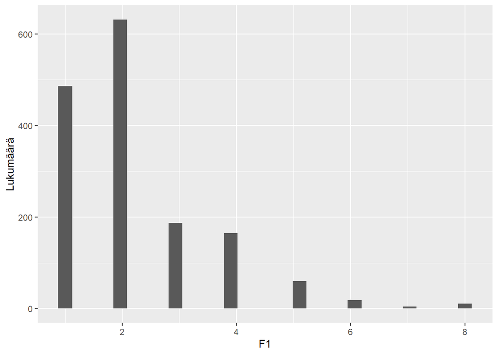

## **F2_sp**: Toisen perheenjäsenen sukupuoli

| Luokka | n | % | % vastanneista |
| --- | --- | --- | --- |
| Mies | 535 | 34.2% | 49.9% |
| Nainen | 538 | 34.4% | 50.1% |
| NA | 490 | 31.3% | - |

## **F3_sp**: Kolmannen perheenjäsenen sukupuoli

| Luokka | n | % | % vastanneista |
| --- | --- | --- | --- |
| Mies | 207 | 13.2% | 46.8% |
| Nainen | 235 | 15.0% | 53.2% |
| NA | 1121 | 71.7% | - |

## **F4_sp**: Neljännen perheenjäsenen sukupuoli

| Luokka | n | % | % vastanneista |
| --- | --- | --- | --- |
| Mies | 130 | 8.3% | 50.8% |
| Nainen | 126 | 8.1% | 49.2% |
| NA | 1307 | 83.6% | - |

## **F5_sp**: Viidennen perheenjäsenen sukupuoli

| Luokka | n | % | % vastanneista |
| --- | --- | --- | --- |
| Mies | 50 | 3.2% | 54.3% |
| Nainen | 42 | 2.7% | 45.7% |
| NA | 1471 | 94.1% | - |

## **F6_sp**: Kuudennen perheenjäsenen sukupuoli

| Luokka | n | % | % vastanneista |
| --- | --- | --- | --- |
| Mies | 15 | 1.0% | 44.1% |
| Nainen | 19 | 1.2% | 55.9% |
| NA | 1529 | 97.8% | - |

## **F7_sp**: Seitsemännen perheenjäsenen sukupuoli

| Luokka | n | % | % vastanneista |
| --- | --- | --- | --- |
| Mies | 8 | 0.5% | 53.3% |
| Nainen | 7 | 0.4% | 46.7% |
| NA | 1548 | 99.0% | - |

## **F2_syntymävuosi**: Toisen perheenjäsenen syntymävuosi

| Tieto | Arvo |
| --- | --- |
| Vastanneita | 1051.00 |
| Keskiarvo | 1970.72 |
| Keskihajonta | 18.28 |
| Minimi | 1934.00 |
| Maksimi | 2022.00 |

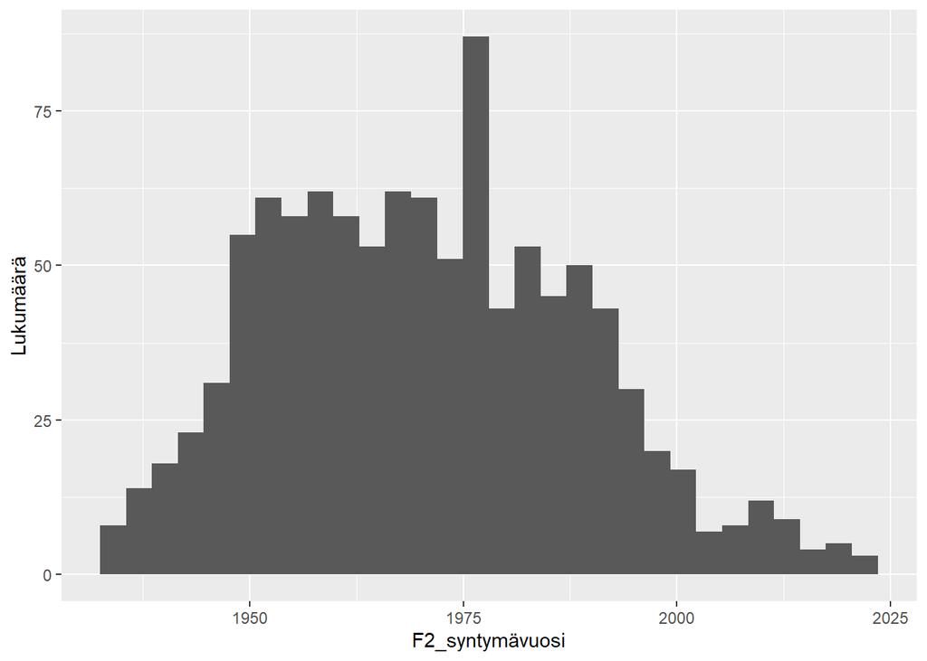

## **F3_syntymävuosi**: Kolmannen perheenjäsenen syntymävuosi

| Tieto | Arvo |
| --- | --- |
| Vastanneita | 428.00 |
| Keskiarvo | 2004.13 |
| Keskihajonta | 14.87 |
| Minimi | 1939.00 |
| Maksimi | 2023.00 |

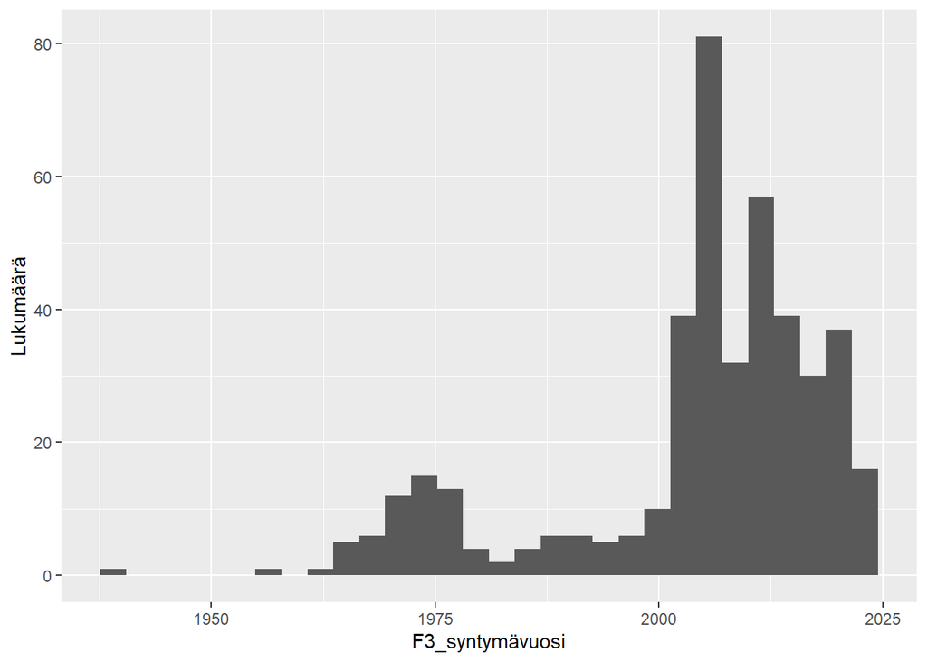

## **F4_syntymävuosi**: Neljännen perheenjäsenen syntymävuosi

| Tieto | Arvo |
| --- | --- |
| Vastanneita | 256.00 |
| Keskiarvo | 2011.15 |
| Keskihajonta | 7.62 |
| Minimi | 1935.00 |
| Maksimi | 2023.00 |

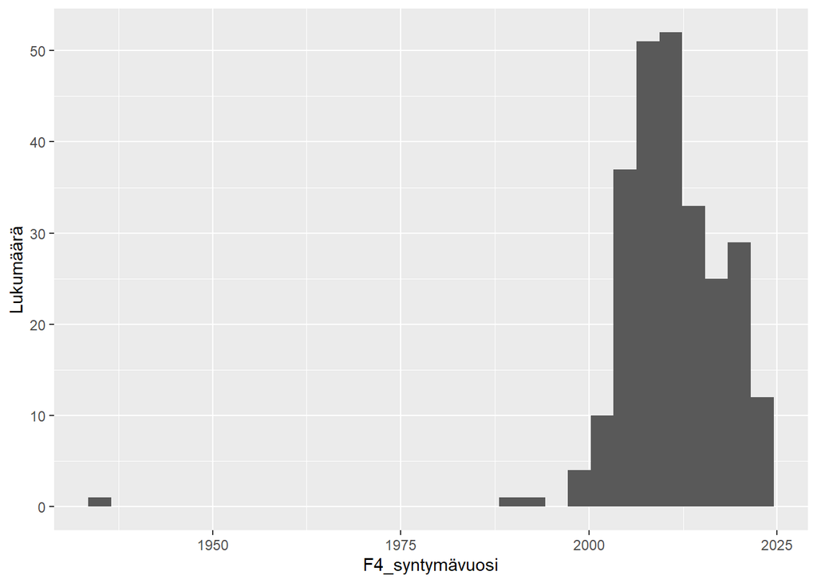

## **F5_syntymävuosi**: Viidennen perheenjäsenen syntymävuosi

| Tieto | Arvo |
| --- | --- |
| Vastanneita | 92.00 |
| Keskiarvo | 2012.78 |
| Keskihajonta | 4.87 |
| Minimi | 1996.00 |
| Maksimi | 2023.00 |

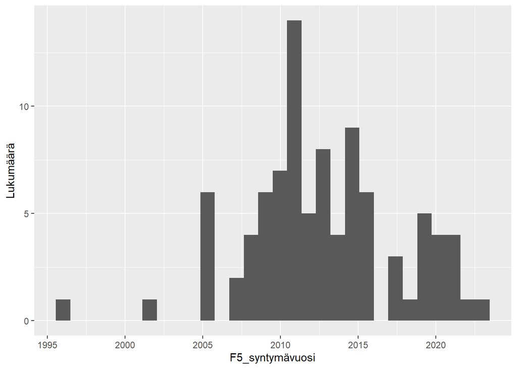

## **F6_syntymävuosi**: Kuudennen perheenjäsenen syntymävuosi

| Tieto | Arvo |
| --- | --- |
| Vastanneita | 33.00 |
| Keskiarvo | 2014.70 |
| Keskihajonta | 5.89 |
| Minimi | 1999.00 |
| Maksimi | 2023.00 |

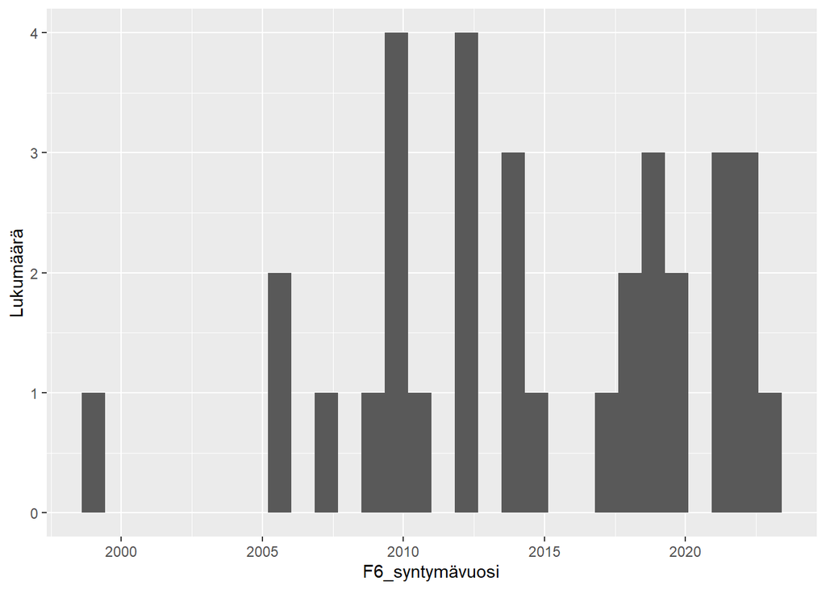

## **F7_syntymävuosi**: Seitsemännen perheenjäsenen syntymävuosi

| Tieto | Arvo |
| --- | --- |
| Vastanneita | 14.00 |
| Keskiarvo | 2013.64 |
| Keskihajonta | 5.40 |
| Minimi | 2002.00 |
| Maksimi | 2022.00 |

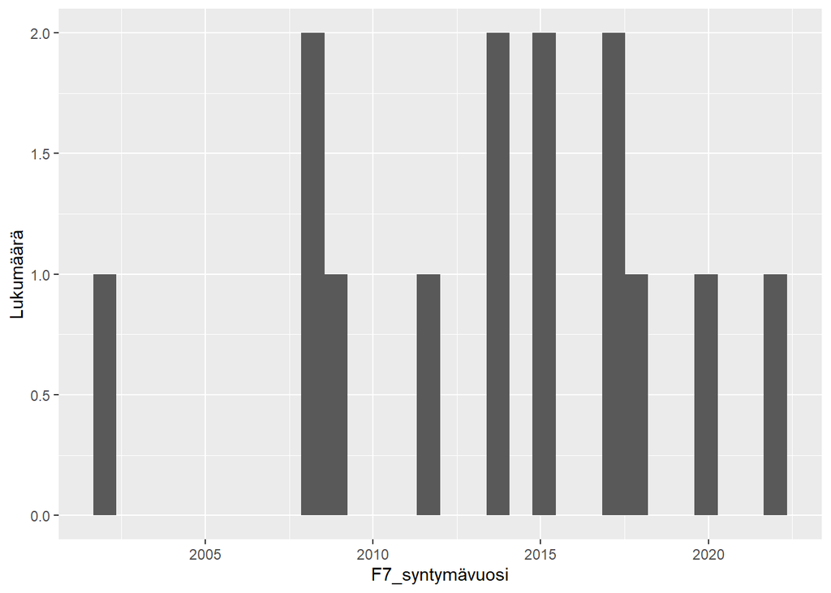

## **F2_suhde**: Toisen perheenjäsenen sukulaisuussuhde vastaajaan

| Luokka | n | % | % vastanneista |
| --- | --- | --- | --- |
| Mies/vaimo/kumppani | 921 | 58.9% | 85.8% |
| Poika/tytär (mukaan lukien lapsipuoli, adoptiolapsi, sijaislapsi, puolison lapsi) | 56 | 3.6% | 5.2% |
| Vanhempi/appivanhempi/avopuolison vanhempi/äiti- tai isäpuoli | 85 | 5.4% | 7.9% |
| Veli/sisko (mukaan lukien veli-/siskopuoli, adoptoidut ja sijaisveli/-sisko) | 8 | 0.5% | 0.7% |
| Muu ei-sukulainen | 4 | 0.3% | 0.4% |
| NA | 489 | 31.3% | - |

## **F3_suhde**: Kolmannen perheenjäsenen sukulaisuussuhde vastaajaan

| Luokka | n | % | % vastanneista |
| --- | --- | --- | --- |
| Mies/vaimo/kumppani | 5 | 0.3% | 1.1% |
| Poika/tytär (mukaan lukien lapsipuoli, adoptiolapsi, sijaislapsi, puolison lapsi) | 357 | 22.8% | 80.6% |
| Vanhempi/appivanhempi/avopuolison vanhempi/äiti- tai isäpuoli | 71 | 4.5% | 16.0% |
| Veli/sisko (mukaan lukien veli-/siskopuoli, adoptoidut ja sijaisveli/-sisko) | 9 | 0.6% | 2.0% |
| Muu ei-sukulainen | 1 | 0.1% | 0.2% |
| NA | 1120 | 71.7% | - |

## **F4_suhde**: Neljännen perheenjäsenen sukulaisuussuhde vastaajaan

| Luokka | n | % | % vastanneista |
| --- | --- | --- | --- |
| Poika/tytär (mukaan lukien lapsipuoli, adoptiolapsi, sijaislapsi, puolison lapsi) | 208 | 13.3% | 80.6% |
| Vanhempi/appivanhempi/avopuolison vanhempi/äiti- tai isäpuoli | 1 | 0.1% | 0.4% |
| Veli/sisko (mukaan lukien veli-/siskopuoli, adoptoidut ja sijaisveli/-sisko) | 47 | 3.0% | 18.2% |
| Muu sukulainen | 1 | 0.1% | 0.4% |
| Muu ei-sukulainen | 1 | 0.1% | 0.4% |
| NA | 1305 | 83.5% | - |

## **F5_suhde**: Viidennen perheenjäsenen sukulaisuussuhde vastaajaan

| Luokka | n | % | % vastanneista |
| --- | --- | --- | --- |
| Poika/tytär (mukaan lukien lapsipuoli, adoptiolapsi, sijaislapsi, puolison lapsi) | 70 | 4.5% | 75.3% |
| Veli/sisko (mukaan lukien veli-/siskopuoli, adoptoidut ja sijaisveli/-sisko) | 22 | 1.4% | 23.7% |
| Muu sukulainen | 1 | 0.1% | 1.1% |
| NA | 1470 | 94.0% | - |

## **F6_suhde**: Kuudennen perheenjäsenen sukulaisuussuhde vastaajaan

| Luokka | n | % | % vastanneista |
| --- | --- | --- | --- |
| Poika/tytär (mukaan lukien lapsipuoli, adoptiolapsi, sijaislapsi, puolison lapsi) | 24 | 1.5% | 70.6% |
| Veli/sisko (mukaan lukien veli-/siskopuoli, adoptoidut ja sijaisveli/-sisko) | 10 | 0.6% | 29.4% |
| NA | 1529 | 97.8% | - |

## **F7_suhde**: Seitsemännen perheenjäsenen sukulaisuussuhde vastaajaan

| Luokka | n | % | % vastanneista |
| --- | --- | --- | --- |
| Son/daughter/step/adopted/foster | 8 | 0.5% | 53.3% |
| Brother/sister/step/adopted/foster | 7 | 0.4% | 46.7% |
| NA | 1548 | 99.0% | - |

## **F6**: Mikä vaihtoehdoista kuvaa parhaiten suhdettasi puolisoosi/avopuolisoosi, jonka kanssa asut?

| Luokka | n | % | % vastanneista |
| --- | --- | --- | --- |
| Avioliitto | 690 | 44.1% | 75.0% |
| Avoliitto | 229 | 14.7% | 24.9% |
| Eronnut / Rekisteröity parisuhde purettu | 1 | 0.1% | 0.1% |
| NA | 643 | 41.1% | - |

## **F7**: Oletko koskaan asunut yhdessä jonkun kumppanin kanssa ilman, että olet ollut naimisissa tai rekisteröidyssä parisuhteessa hänen kanssaan?

| Luokka | n | % | % vastanneista |
| --- | --- | --- | --- |
| Kyllä | 744 | 47.6% | 56.1% |
| En | 582 | 37.2% | 43.9% |
| NA | 237 | 15.2% | - |

## **F8**: Oletko koskaan eronnut avioliitosta tai rekisteröidystä parisuhteesta?

| Luokka | n | % | % vastanneista |
| --- | --- | --- | --- |
| Kyllä | 359 | 23.0% | 23.0% |
| En | 1199 | 76.7% | 77.0% |
| NA | 5 | 0.3% | - |

## **F11**: Mikä on laillinen sivilisäätysi tällä hetkellä?

| Luokka | n | % | % vastanneista |
| --- | --- | --- | --- |
| Avioliitto | 28 | 1.8% | 3.2% |
| Eronnut / Rekisteröity parisuhde purettu | 230 | 14.7% | 26.4% |
| Leski / Rekisteröidyn parisuhteen toinen osapuoli on kuollut | 103 | 6.6% | 11.8% |
| Ei mikään näistä (ei ole koskaan ollut naimisissa tai rekisteröidyssä parisuhteessa) | 509 | 32.6% | 58.5% |
| NA | 693 | 44.3% | - |

## **F13**: Oletko koskaan asunut samassa kotitaloudessa omien tai puolisosi lasten, adoptio- tai sijaislasten kanssa?

| Luokka | n | % | % vastanneista |
| --- | --- | --- | --- |
| Kyllä | 628 | 40.2% | 54.0% |
| En | 536 | 34.3% | 46.0% |
| NA | 399 | 25.5% | - |

## **F14**: Mikä vaihtoehdoista kuvaa parhaiten asuinympäristöäsi?

| Luokka | n | % | % vastanneista |
| --- | --- | --- | --- |
| Suuri kaupunki | 226 | 14.5% | 14.5% |
| Suuren kaupungin lähiö tai lähiseutu | 372 | 23.8% | 23.8% |
| Pieni tai keskikokoinen kaupunki tai kunta | 553 | 35.4% | 35.4% |
| Pienempi taajama tai kunta | 205 | 13.1% | 13.1% |
| Maaseutu / haja-asutusalue | 207 | 13.2% | 13.2% |

## **F14a_1**: Liittyykö asuntoosi jokin ongelma? Home tai laho ikkunoissa, ovissa ja lattioissa

| Luokka | n | % | % vastanneista |
| --- | --- | --- | --- |
| Ei mainittu | 1543 | 98.7% | 98.7% |
| Mainittu | 20 | 1.3% | 1.3% |

## **F14a_2**: Liittyykö asuntoosi jokin ongelma? Kosteat seinät tai vuotava katto

| Luokka | n | % | % vastanneista |
| --- | --- | --- | --- |
| Ei mainittu | 1541 | 98.6% | 98.6% |
| Mainittu | 22 | 1.4% | 1.4% |

## **F14a_3**: Liittyykö asuntoosi jokin ongelma? Sisätiloissa ei ole vesivessaa

| Luokka | n | % | % vastanneista |
| --- | --- | --- | --- |
| Ei mainittu | 1560 | 99.8% | 99.8% |
| Mainittu | 3 | 0.2% | 0.2% |

## **F14a_4**: Liittyykö asuntoosi jokin ongelma? Ei ammetta eikä suihkua

| Luokka | n | % | % vastanneista |
| --- | --- | --- | --- |
| Ei mainittu | 1561 | 99.9% | 99.9% |
| Mainittu | 2 | 0.1% | 0.1% |

## **F14a_5**: Liittyykö asuntoosi jokin ongelma? Liian suuri määrä ihmisiä

| Luokka | n | % | % vastanneista |
| --- | --- | --- | --- |
| Ei mainittu | 1535 | 98.2% | 98.2% |
| Mainittu | 28 | 1.8% | 1.8% |

## **F14a_6**: Liittyykö asuntoosi jokin ongelma? Erittäin kuuma tai kylmä

| Luokka | n | % | % vastanneista |
| --- | --- | --- | --- |
| Ei mainittu | 1465 | 93.7% | 93.7% |
| Mainittu | 98 | 6.3% | 6.3% |

## **F14a_7**: Liittyykö asuntoosi jokin ongelma? Melu

| Luokka | n | % | % vastanneista |
| --- | --- | --- | --- |
| Ei mainittu | 1512 | 96.7% | 96.7% |
| Mainittu | 51 | 3.3% | 3.3% |

## **F14a_8**: Liittyykö asuntoosi jokin ongelma? Hyönteiset tai jyrsijät

| Luokka | n | % | % vastanneista |
| --- | --- | --- | --- |
| Ei mainittu | 1487 | 95.1% | 95.1% |
| Mainittu | 76 | 4.9% | 4.9% |

## **F14a_9**: Liittyykö asuntoosi jokin ongelma? Ei mitään näistä

| Luokka | n | % | % vastanneista |
| --- | --- | --- | --- |
| Ei mainittu | 256 | 16.4% | 16.4% |
| Mainittu | 1307 | 83.6% | 83.6% |

## **F14a_10**: Liittyykö asuntoosi jokin ongelma? Ei halua vastata

| Luokka | n | % | % vastanneista |
| --- | --- | --- | --- |
| Ei mainittu | 1563 | 100.0% | 100.0% |

## **F15**: Mikä on korkein koulutusaste, jonka olet suorittanut?

| Luokka | n | % | % vastanneista |
| --- | --- | --- | --- |
| Vähemmän kuin peruskoulun ala-aste tai vähemmän kuin peruskoulu | 6 | 0.4% | 0.4% |
| Peruskoulun ala-aste, kansakoulu tai kansalaiskoulu | 109 | 7.0% | 7.0% |
| Peruskoulun yläaste tai keskikoulu | 138 | 8.8% | 8.8% |
| Lukio, ylioppilastutkinto | 99 | 6.3% | 6.3% |
| Ammatillinen perustutkinto, ammattitutkinto | 367 | 23.5% | 23.5% |
| Sekä ylioppilas- että ammattitutkinto | 37 | 2.4% | 2.4% |
| Erikoisammattitutkinto | 55 | 3.5% | 3.5% |
| Ammatillinen opistoasteen tutkinto | 157 | 10.0% | 10.1% |
| Ammattikorkeakoulututkinto tai ammatillisen korkea-asteen tutkinto | 180 | 11.5% | 11.5% |
| Alempi korkeakoulututkinto tai kandidaatin tutkinto | 93 | 6.0% | 6.0% |
| Ylempi ammattikorkeakoulututkinto | 44 | 2.8% | 2.8% |
| Ylempi korkeakoulututkinto | 244 | 15.6% | 15.6% |
| Lisensiaatin tutkinto | 15 | 1.0% | 1.0% |
| Tohtorin tutkinto | 17 | 1.1% | 1.1% |
| Jokin muu | 1 | 0.1% | 0.1% |
| NA | 1 | 0.1% | - |

## **F16**: Kuinka monta vuotta yhteensä olet ollut koulussa tai opiskelemassa kokopäiväisesti tai osa-aikaisesti?

| Tieto | Arvo |
| --- | --- |
| Vastanneita | 1557.00 |
| Keskiarvo | 14.56 |
| Keskihajonta | 4.24 |
| Minimi | 2.00 |
| Maksimi | 40.00 |

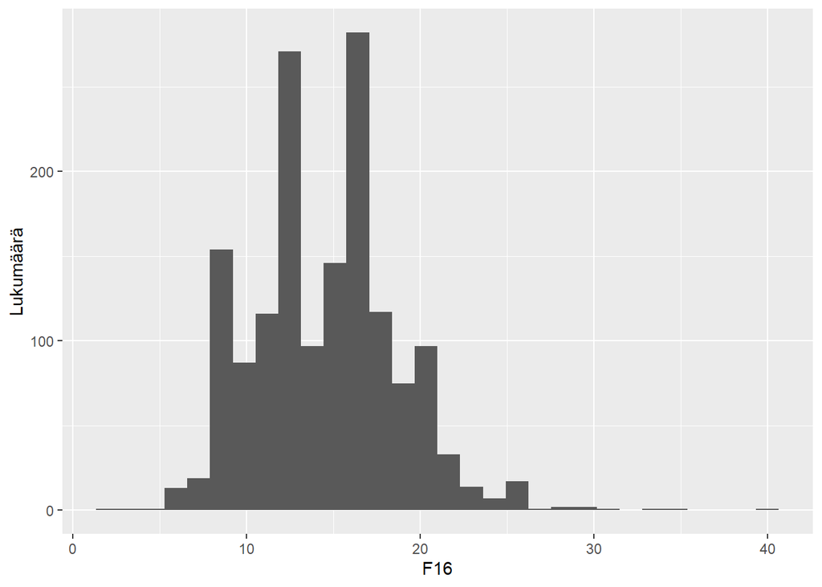

## **F17a_1**: Mitä olet tehnyt viimeisten seitsemän päivän aikana? Ansiotyössä tai tilapäisesti pois ansiotyöstä (työntekijä, yrittäjä, maanviljelijä, avustava perheenjäsen jne.)

| Luokka | n | % | % vastanneista |
| --- | --- | --- | --- |
| Ei mainittu | 735 | 47.0% | 47.0% |
| Mainittu | 828 | 53.0% | 53.0% |

## **F17a_2**: Mitä olet tehnyt viimeisten seitsemän päivän aikana? Opiskelija (ei työnantajan maksama koulutus, mukaan lukien lomalla)

| Luokka | n | % | % vastanneista |
| --- | --- | --- | --- |
| Ei mainittu | 1370 | 87.7% | 87.7% |
| Mainittu | 193 | 12.3% | 12.3% |

## **F17a_3**: Mitä olet tehnyt viimeisten seitsemän päivän aikana? Työtön, hakee aktiivisesti työtä

| Luokka | n | % | % vastanneista |
| --- | --- | --- | --- |
| Ei mainittu | 1524 | 97.5% | 97.5% |
| Mainittu | 39 | 2.5% | 2.5% |

## **F17a_4**: Mitä olet tehnyt viimeisten seitsemän päivän aikana? Työtön, haluaa töihin, mutta ei aktiivisesti hae työtä

| Luokka | n | % | % vastanneista |
| --- | --- | --- | --- |
| Ei mainittu | 1539 | 98.5% | 98.5% |
| Mainittu | 24 | 1.5% | 1.5% |

## **F17a_5**: Mitä olet tehnyt viimeisten seitsemän päivän aikana? Pysyvästi sairas tai työkyvytön

| Luokka | n | % | % vastanneista |
| --- | --- | --- | --- |
| Ei mainittu | 1535 | 98.2% | 98.2% |
| Mainittu | 28 | 1.8% | 1.8% |

## **F17a_6**: Mitä olet tehnyt viimeisten seitsemän päivän aikana? Eläkkeellä

| Luokka | n | % | % vastanneista |
| --- | --- | --- | --- |
| Ei mainittu | 985 | 63.0% | 63.0% |
| Mainittu | 578 | 37.0% | 37.0% |

## **F17a_7**: Mitä olet tehnyt viimeisten seitsemän päivän aikana? Varusmies- tai siviilipalvelussa

| Luokka | n | % | % vastanneista |
| --- | --- | --- | --- |
| Ei mainittu | 1559 | 99.7% | 99.7% |
| Mainittu | 4 | 0.3% | 0.3% |

## **F17a_8**: Mitä olet tehnyt viimeisten seitsemän päivän aikana? Kotiäiti tai -isä, omaishoitaja tms., hoitaa lapsia tai muuta henkilöä/muita henkilöitä

| Luokka | n | % | % vastanneista |
| --- | --- | --- | --- |
| Ei mainittu | 1520 | 97.2% | 97.2% |
| Mainittu | 43 | 2.8% | 2.8% |

## **F17c**: Jos vastaaja on tehnyt useampia F17-patterin vaihtoehdoista: mikä vaihtoehdoista kuvaa parhaiten sitä, mitä olet tehnyt viimeisten seitsemän päivän aikana?

| Luokka | n | % | % vastanneista |
| --- | --- | --- | --- |
| Ansiotyössä tai tilapäisesti pois ansiotyöstä (työntekijä, yrittäjä, maanviljelijä, avustava perheenjäsen jne | 93 | 6.0% | 53.1% |
| Opiskelija (ei työnantajan maksama koulutus, mukaan lukien lomalla) | 36 | 2.3% | 20.6% |
| Työtön, hakee aktiivisesti töitä | 3 | 0.2% | 1.7% |
| Työtön, haluaa töihin, mutta ei aktiivisesti hae työtä | 3 | 0.2% | 1.7% |
| Pysyvästi sairas tai työkyvytön | 5 | 0.3% | 2.9% |
| Eläkkeellä | 23 | 1.5% | 13.1% |
| Kotiäiti tai -isä, omaishoitaja tms., hoitaa lapsia tai muuta henkilöä/muita henkilöitä | 12 | 0.8% | 6.9% |
| NA | 1388 | 88.8% | - |

## **F18**: Oletko tehnyt ansiotyötä vähintään yhden tunnin ajan viimeisten seitsemän päivän aikana?

| Luokka | n | % | % vastanneista |
| --- | --- | --- | --- |
| Kyllä | 19 | 1.2% | 2.6% |
| Ei | 715 | 45.7% | 97.4% |
| NA | 829 | 53.0% | - |

## **F19**: Oletko koskaan ollut ansiotyössä?

| Luokka | n | % | % vastanneista |
| --- | --- | --- | --- |
| Kyllä | 694 | 44.4% | 97.1% |
| Ei | 21 | 1.3% | 2.9% |
| NA | 848 | 54.3% | - |

## **F20**: Minä vuonna olit viimeksi ansiotyössä?

| Tieto | Arvo |
| --- | --- |
| Vastanneita | 685.00 |
| Keskiarvo | 2013.08 |
| Keskihajonta | 9.91 |
| Minimi | 1956.00 |
| Maksimi | 2023.00 |

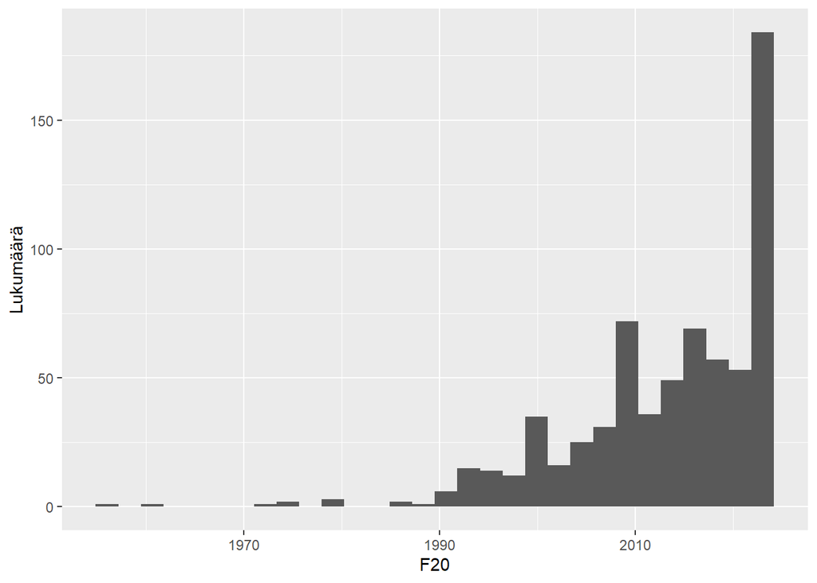

## **F21**: Mikä on työsuhteesi luonne?

| Luokka | n | % | % vastanneista |
| --- | --- | --- | --- |
| Palkansaaja | 1332 | 85.2% | 86.5% |
| Yrittäjä | 185 | 11.8% | 12.0% |
| Työssä perheyrityksessä, maatilalla tai avustava perheenjäsen | 23 | 1.5% | 1.5% |
| NA | 23 | 1.5% | - |

## **F22**: Kuinka monta palkattua työntekijää sinulla on/oli?

| Tieto | Arvo |
| --- | --- |
| Vastanneita | 185.00 |
| Keskiarvo | 2.45 |
| Keskihajonta | 5.76 |
| Minimi | 0.00 |
| Maksimi | 40.00 |

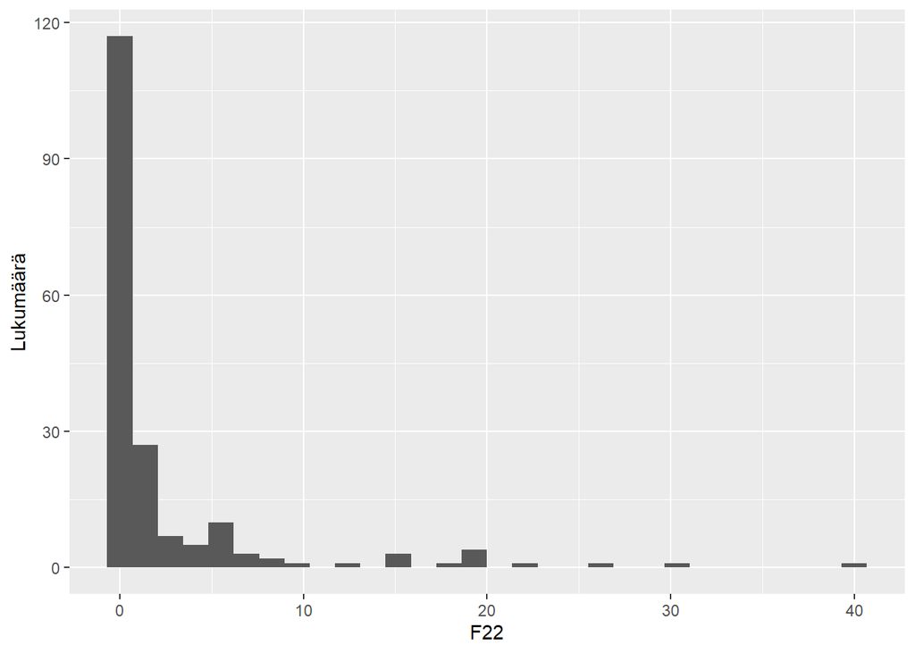

## **F23**: Onko/oliko työsuhteesi vakituinen vai määräaikainen?

| Luokka | n | % | % vastanneista |
| --- | --- | --- | --- |
| Vakituinen | 1031 | 66.0% | 76.3% |
| Määräaikainen | 287 | 18.4% | 21.2% |
| Ei ole / ollut työsopimusta | 33 | 2.1% | 2.4% |
| NA | 212 | 13.6% | - |

## **F24**: Kuinka monta henkilöä työpaikallasi työskentelee/työskenteli sinut itsesi mukaan lukien?

| Luokka | n | % | % vastanneista |
| --- | --- | --- | --- |
| Alle 10 | 437 | 28.0% | 28.8% |
| 10-24 | 328 | 21.0% | 21.7% |
| 25-99 | 364 | 23.3% | 24.0% |
| 100-499 | 201 | 12.9% | 13.3% |
| 500 tai enemmän | 185 | 11.8% | 12.2% |
| NA | 48 | 3.1% | - |

## **F25**: Onko/oliko sinulla päätyössäsi alaisia tai kuuluiko tehtäviisi ohjata muiden tekemää työtä?

| Luokka | n | % | % vastanneista |
| --- | --- | --- | --- |
| Kyllä | 429 | 27.4% | 27.9% |
| Ei | 1111 | 71.1% | 72.1% |
| NA | 23 | 1.5% | - |

## **F26**: Kuinka monta alaista sinulla on/oli?

| Tieto | Arvo |
| --- | --- |
| Vastanneita | 417.00 |
| Keskiarvo | 15.60 |
| Keskihajonta | 41.53 |
| Minimi | 1.00 |
| Maksimi | 500.00 |

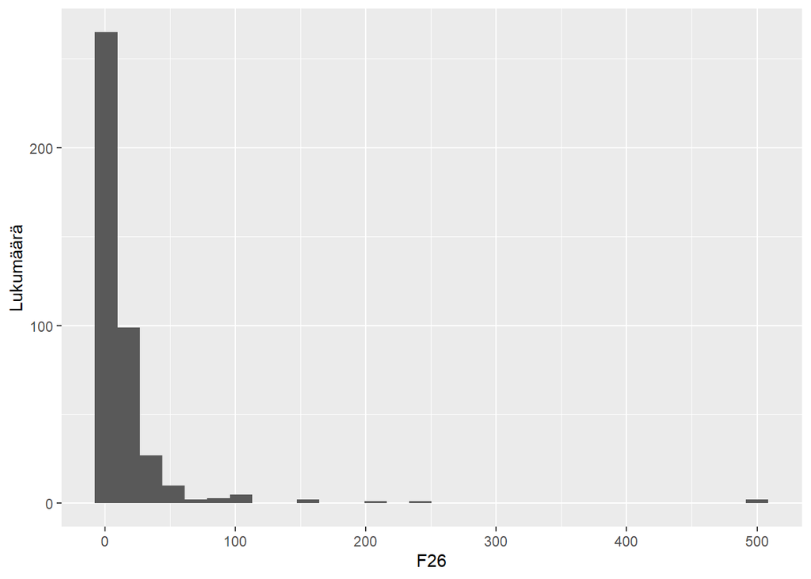

## **F27**: Kuinka paljon työpaikkasi johto antaa/antoi sinun päättää siitä, kuinka päivittäinen työsi järjestetään/järjestettiin?

| Luokka | n | % | % vastanneista |
| --- | --- | --- | --- |
| En voi/voinut vaikuttaa ollenkaan | 39 | 2.5% | 2.6% |
| 1 | 26 | 1.7% | 1.7% |
| 2 | 47 | 3.0% | 3.1% |
| 3 | 43 | 2.8% | 2.8% |
| 4 | 36 | 2.3% | 2.4% |
| 5 | 73 | 4.7% | 4.8% |
| 6 | 71 | 4.5% | 4.6% |
| 7 | 168 | 10.7% | 11.0% |
| 8 | 320 | 20.5% | 21.0% |
| 9 | 365 | 23.4% | 23.9% |
| Voin päättää kokonaan itse | 339 | 21.7% | 22.2% |
| NA | 36 | 2.3% | - |

## **F28**: Kuinka paljon työpaikkasi johto antaa/antoi sinun vaikuttaa organisaation toiminnasta tehtäviin periaateratkaisuihin?

| Luokka | n | % | % vastanneista |
| --- | --- | --- | --- |
| En voi/voinut vaikuttaa ollenkaan | 157 | 10.0% | 10.4% |
| 1 | 93 | 6.0% | 6.2% |
| 2 | 115 | 7.4% | 7.6% |
| 3 | 114 | 7.3% | 7.5% |
| 4 | 84 | 5.4% | 5.6% |
| 5 | 155 | 9.9% | 10.3% |
| 6 | 127 | 8.1% | 8.4% |
| 7 | 185 | 11.8% | 12.2% |
| 8 | 200 | 12.8% | 13.2% |
| 9 | 109 | 7.0% | 7.2% |
| Voin päättää kokonaan itse | 172 | 11.0% | 11.4% |
| NA | 52 | 3.3% | - |

## **F29**: Mikä on/oli säännöllinen viikkotyöaikasi päätyössäsi pois lukien ylityöt?

| Tieto | Arvo |
| --- | --- |
| Vastanneita | 1517.00 |
| Keskiarvo | 34.29 |
| Keskihajonta | 13.83 |
| Minimi | 0.00 |
| Maksimi | 112.00 |

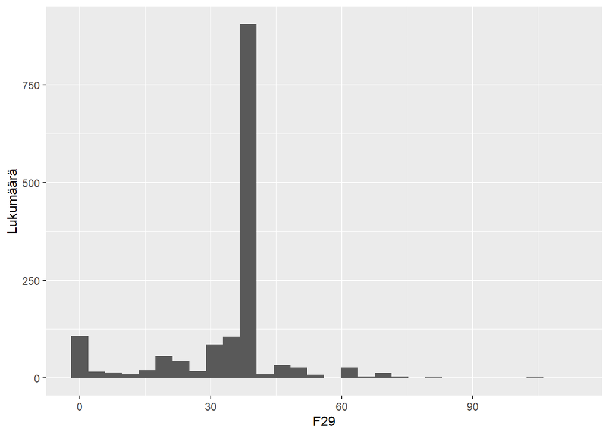

## **F30**: Kuinka monta tuntia työskentelet/työskentelit päätyössäsi tavallisesti normaalin viikon aikana mukaan lukien ylityöt?

| Tieto | Arvo |
| --- | --- |
| Vastanneita | 1497.00 |
| Keskiarvo | 36.53 |
| Keskihajonta | 13.67 |
| Minimi | 0.00 |
| Maksimi | 112.00 |

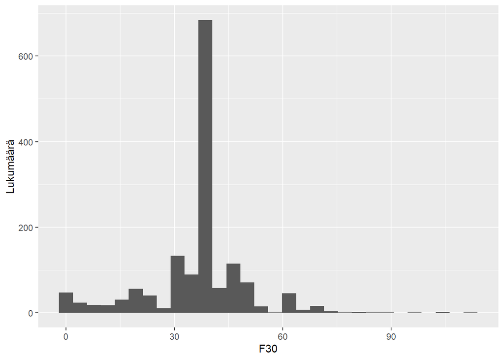

## **F32**: Minkä tyyppisen työnantajan palveluksessa olet/olit?

| Luokka | n | % | % vastanneista |
| --- | --- | --- | --- |
| Keskus- tai paikallishallinto | 71 | 4.5% | 4.6% |
| Muu julkinen sektori (esim. koulutus- tai terveyspalvelut) | 386 | 24.7% | 25.2% |
| Julkisen sektorin omistama yritys | 122 | 7.8% | 8.0% |
| Yksityinen yritys | 714 | 45.7% | 46.6% |
| Yksityisyrittäjä | 156 | 10.0% | 10.2% |
| Muu | 84 | 5.4% | 5.5% |
| NA | 30 | 1.9% | - |

## **F35**: Oletko viimeisen 10 vuoden aikana ollut ansiotyössä ulkomailla vähintään 6 kuukauden pituisen jakson?

| Luokka | n | % | % vastanneista |
| --- | --- | --- | --- |
| Kyllä | 46 | 2.9% | 3.0% |
| Ei | 1494 | 95.6% | 97.0% |
| NA | 23 | 1.5% | - |

## **F36**: Oletko koskaan ollut työttömänä työnhakijana yhtäjaksoisesti yli kolmen kuukauden pituisen jakson?

| Luokka | n | % | % vastanneista |
| --- | --- | --- | --- |
| Kyllä | 552 | 35.3% | 35.5% |
| Ei | 1004 | 64.2% | 64.5% |
| NA | 7 | 0.4% | - |

## **F37**: Oletko koskaan ollut työttömänä työnhakijana yhtäjaksoisesti 12 kuukautta tai kauemmin?

| Luokka | n | % | % vastanneista |
| --- | --- | --- | --- |
| Kyllä | 210 | 13.4% | 38.5% |
| Ei | 335 | 21.4% | 61.5% |
| NA | 1018 | 65.1% | - |

## **F38**: Oletko ollut työttömänä työnhakijana viimeisen viiden vuoden aikana?

| Luokka | n | % | % vastanneista |
| --- | --- | --- | --- |
| Kyllä | 160 | 10.2% | 29.0% |
| Ei | 391 | 25.0% | 71.0% |
| NA | 1012 | 64.7% | - |

## **F39**: Oletko nykyisin tai oletko joskus ollut jonkin ammattiliiton tai vastaavan jäsen?

| Luokka | n | % | % vastanneista |
| --- | --- | --- | --- |
| Kyllä, olen tällä hetkellä | 641 | 41.0% | 41.1% |
| Kyllä, olen aiemmin ollut | 575 | 36.8% | 36.9% |
| Ei | 342 | 21.9% | 22.0% |
| NA | 5 | 0.3% | - |

## **F40**: Mikä on kotitaloutesi pääasiallisin toimeentulon lähde?

| Luokka | n | % | % vastanneista |
| --- | --- | --- | --- |
| Palkkatulot | 833 | 53.3% | 53.4% |
| Tulot omasta yrityksestä (ei maatilalta) | 72 | 4.6% | 4.6% |
| Tulot maatilalta | 15 | 1.0% | 1.0% |
| Eläketulot | 527 | 33.7% | 33.8% |
| Työttömyysturva | 31 | 2.0% | 2.0% |
| Muut sosiaalietuudet tai -tuet | 65 | 4.2% | 4.2% |
| Sijoitustulot, säästöt, pääomatulot | 14 | 0.9% | 0.9% |
| Muut tulot | 4 | 0.3% | 0.3% |
| NA | 2 | 0.1% | - |

## **F41**: Kuinka paljon taloutesi nettotulot eli tulot verojen jälkeen ovat yhteensä kuukaudessa?

| Luokka | n | % | % vastanneista |
| --- | --- | --- | --- |
| 1. tulodesiili (korkeintaan 1249 euroa). | 112 | 7.2% | 7.5% |
| 2. tulodesiili (1 250 – 1 549 euroa). | 94 | 6.0% | 6.3% |
| 3. tulodesiili (1 550 – 1 899 euroa). | 96 | 6.1% | 6.5% |
| 4. tulodesiili (1 900 – 2 399 euroa). | 131 | 8.4% | 8.8% |
| 5. tulodesiili (2 400 – 2 799 euroa). | 140 | 9.0% | 9.4% |
| 6. tulodesiili (2 800 – 3 399 euroa). | 178 | 11.4% | 12.0% |
| 7. tulodesiili (3 400 – 4 149 euroa). | 194 | 12.4% | 13.1% |
| 8. tulodesiili (4 150 – 5 099 euroa). | 212 | 13.6% | 14.3% |
| 9. tulodesiili (5 100 – 6 499 euroa). | 149 | 9.5% | 10.0% |
| 10. tulodesiili (vähintään 6 500 euroa). | 178 | 11.4% | 12.0% |
| NA | 79 | 5.1% | - |

## **F42**: Minkälaiset kotitaloutesi tulot ovat tällä hetkellä?

| Luokka | n | % | % vastanneista |
| --- | --- | --- | --- |
| Nykyisillä tuloilla elää mukavasti | 497 | 31.8% | 31.9% |
| Nykyisillä tuloilla tulee toimeen | 870 | 55.7% | 55.9% |
| Nykyisillä tuloilla on vaikeuksia tulla toimeen | 161 | 10.3% | 10.3% |
| Nykyisillä tuloilla on hyvin vaikea tulla toimeen | 29 | 1.9% | 1.9% |
| NA | 6 | 0.4% | - |

## **F44**: Mikä on korkein koulutusaste, jonka puolisosi/kumppanisi on suorittanut?

| Luokka | n | % | % vastanneista |
| --- | --- | --- | --- |
| Vähemmän kuin peruskoulun ala-aste tai vähemmän kuin peruskoulu | 4 | 0.3% | 0.4% |
| Peruskoulun ala-aste, kansakoulu tai kansalaiskoulu | 46 | 2.9% | 5.0% |
| Peruskoulun yläaste tai keskikoulu | 39 | 2.5% | 4.3% |
| Lukio, ylioppilastutkinto | 47 | 3.0% | 5.1% |
| Ammatillinen perustutkinto, ammattitutkinto | 235 | 15.0% | 25.7% |
| Sekä ylioppilas- että ammattitutkinto | 33 | 2.1% | 3.6% |
| Erikoisammattitutkinto | 28 | 1.8% | 3.1% |
| Ammatillinen opistoasteen tutkinto | 93 | 6.0% | 10.2% |
| Ammattikorkeakoulututkinto tai ammatillisen korkea-asteen tutkinto | 106 | 6.8% | 11.6% |
| Alempi korkeakoulututkinto tai kandidaatin tutkinto | 55 | 3.5% | 6.0% |
| Ylempi ammattikorkeakoulututkinto | 27 | 1.7% | 3.0% |
| Ylempi korkeakoulututkinto | 163 | 10.4% | 17.8% |
| Lisensiaatin tutkinto | 17 | 1.1% | 1.9% |
| Tohtorin tutkinto | 21 | 1.3% | 2.3% |
| Other | 1 | 0.1% | 0.1% |
| NA | 648 | 41.5% | - |

## **F45a_1**: Mitä puolisosi/kumppanisi on tehnyt viimeisten seitsemän päivän aikana? Ansiotyössä tai tilapäisesti pois ansiotyöstä (työntekijä, yrittäjä, maanviljelijä, avustava perheenjäsen jne.)

| Luokka | n | % | % vastanneista |
| --- | --- | --- | --- |
| Ei mainittu | 1027 | 65.7% | 65.7% |
| Mainittu | 536 | 34.3% | 34.3% |

## **F45a_2**: Mitä puolisosi/kumppanisi on tehnyt viimeisten seitsemän päivän aikana? Opiskelija (ei työnantajan maksama koulutus, mukaan lukien lomalla)

| Luokka | n | % | % vastanneista |
| --- | --- | --- | --- |
| Ei mainittu | 1515 | 96.9% | 96.9% |
| Mainittu | 48 | 3.1% | 3.1% |

## **F45a_3**: Mitä puolisosi/kumppanisi on tehnyt viimeisten seitsemän päivän aikana? Työtön, hakee aktiivisesti työtä

| Luokka | n | % | % vastanneista |
| --- | --- | --- | --- |
| Ei mainittu | 1542 | 98.7% | 98.7% |
| Mainittu | 21 | 1.3% | 1.3% |

## **F45a_4**: Mitä puolisosi/kumppanisi on tehnyt viimeisten seitsemän päivän aikana? Työtön, haluaa töihin, mutta ei aktiivisesti hae työtä

| Luokka | n | % | % vastanneista |
| --- | --- | --- | --- |
| Ei mainittu | 1554 | 99.4% | 99.4% |
| Mainittu | 9 | 0.6% | 0.6% |

## **F45a_5**: Mitä puolisosi/kumppanisi on tehnyt viimeisten seitsemän päivän aikana? Pysyvästi sairas tai työkyvytön

| Luokka | n | % | % vastanneista |
| --- | --- | --- | --- |
| Ei mainittu | 1545 | 98.8% | 98.8% |
| Mainittu | 18 | 1.2% | 1.2% |

## **F45a_6**: Mitä puolisosi/kumppanisi on tehnyt viimeisten seitsemän päivän aikana? Eläkkeellä

| Luokka | n | % | % vastanneista |
| --- | --- | --- | --- |
| Ei mainittu | 1246 | 79.7% | 79.7% |
| Mainittu | 317 | 20.3% | 20.3% |

## **F45a_8**: Mitä puolisosi/kumppanisi on tehnyt viimeisten seitsemän päivän aikana? Kotiäiti tai -isä, omaishoitaja tms., hoitaa lapsia tai muuta henkilöä/muita henkilöitä

| Luokka | n | % | % vastanneista |
| --- | --- | --- | --- |
| Ei mainittu | 1539 | 98.5% | 98.5% |
| Mainittu | 24 | 1.5% | 1.5% |

## **F45a_9**: Mitä puolisosi/kumppanisi on tehnyt viimeisten seitsemän päivän aikana? Joku muu

| Luokka | n | % | % vastanneista |
| --- | --- | --- | --- |
| Ei mainittu | 1561 | 99.9% | 99.9% |
| Mainittu | 2 | 0.1% | 0.1% |

## **F45c**: Mikä kuvauksista parhaiten sopii siihen, mitä puolisosi/kumppanisi on tehnyt viimeisten seitsemän päivän aikana?

| Luokka | n | % | % vastanneista |
| --- | --- | --- | --- |
| Ansiotyössä tai tilapäisesti pois ansiotyöstä (työntekijä, yrittäjä, maanviljelijä, avustava perheenjäsen jne | 32 | 2.0% | 60.4% |
| Opiskelija (ei työnantajan maksama koulutus, mukaan lukien lomalla) | 3 | 0.2% | 5.7% |
| Työtön, hakee aktiivisesti töitä | 1 | 0.1% | 1.9% |
| Pysyvästi sairas tai työkyvytön | 1 | 0.1% | 1.9% |
| Eläkkeellä | 11 | 0.7% | 20.8% |
| Kotiäiti tai -isä, omaishoitaja tms., hoitaa lapsia tai muuta henkilöä/muita henkilöitä | 5 | 0.3% | 9.4% |
| NA | 1510 | 96.6% | - |

## **F46**: Tekikö puolisosi/kumppanisi ollenkaan ansiotyötä vähintään yhden tunnin ajan viimeisten seitsemän päivän aikana?

| Luokka | n | % | % vastanneista |
| --- | --- | --- | --- |
| Kyllä | 13 | 0.8% | 3.4% |
| Ei | 373 | 23.9% | 96.6% |
| NA | 1177 | 75.3% | - |

## **F50**: Onko puolisosi/kumppanisi päätyössään:

| Luokka | n | % | % vastanneista |
| --- | --- | --- | --- |
| Palkansaaja | 465 | 29.8% | 85.0% |
| Yrittäjä | 74 | 4.7% | 13.5% |
| Työssä perheyrityksessä, maatilalla tai avustava perheenjäsen | 8 | 0.5% | 1.5% |
| NA | 1016 | 65.0% | - |

## **F51**: Kuinka monta tuntia puolisosi/kumppanisi tavallisesti työskentelee viikon aikana, mukaan lukien ylityöt?

| Tieto | Arvo |
| --- | --- |
| Vastanneita | 530.00 |
| Keskiarvo | 39.31 |
| Keskihajonta | 9.61 |
| Minimi | 7.00 |
| Maksimi | 100.00 |

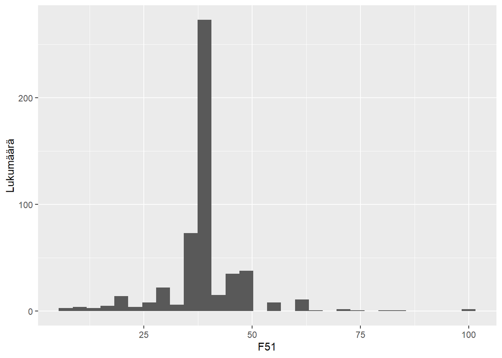

## **Puolison_ammatti_pääluokka**: Puolison ammatti, Ammattiluokitus 2010, pääluokka

| Luokka | n | % | % vastanneista |
| --- | --- | --- | --- |
| Sotilaat | 4 | 0.3% | 0.7% |
| Johtajat | 32 | 2.0% | 5.8% |
| Erityisasiantuntijat | 194 | 12.4% | 35.0% |
| Asiantuntijat | 120 | 7.7% | 21.7% |
| Toimisto- ja asiakaspalvelutyöntekijät | 19 | 1.2% | 3.4% |
| Palvelu- ja myyntityöntekijät | 85 | 5.4% | 15.3% |
| Maanviljelijät, metsätyöntekijät ym. | 15 | 1.0% | 2.7% |
| Rakennus-, korjaus- ja valmistustyöntekijät | 41 | 2.6% | 7.4% |
| Prosessi- ja kuljetustyöntekijät | 25 | 1.6% | 4.5% |
| Muut työntekijät | 19 | 1.2% | 3.4% |
| NA | 1009 | 64.6% | - |

## **Puolison_ammatti_alaluokka**: Puolison ammatti, Ammattiluokitus 2010, 2-numerotason luokka

| Luokka | n | % | % vastanneista |
| --- | --- | --- | --- |
| Upseerit | 4 | 0.3% | 0.7% |
| Johtajat, ylimmät virkamiehet ja järjestöjen johtajat | 2 | 0.1% | 0.4% |
| Hallintojohtajat ja kaupalliset johtajat | 9 | 0.6% | 1.6% |
| Tuotantotoiminnan ja yhteiskunnan peruspalvelujen johtajat | 17 | 1.1% | 3.1% |
| Hotelli- ja ravintola-alan, vähittäiskaupan ja muiden palvelualojen johtajat | 4 | 0.3% | 0.7% |
| Luonnontieteiden ja tekniikan erityisasiantuntijat | 44 | 2.8% | 7.9% |
| Terveydenhuollon erityisasiantuntijat | 13 | 0.8% | 2.3% |
| Opettajat ja muut opetusalan erityisasiantuntijat | 43 | 2.8% | 7.8% |
| Liike-elämän ja hallinnon erityisasiantuntijat | 41 | 2.6% | 7.4% |
| Tieto- ja viestintäteknologian erityisasiantuntijat | 29 | 1.9% | 5.2% |
| Lainopilliset, sosiaalialan ja kulttuurialan erityisasiantuntijat | 24 | 1.5% | 4.3% |
| Luonnontieteiden ja tekniikan asiantuntijat | 12 | 0.8% | 2.2% |
| Terveydenhuollon asiantuntijat | 41 | 2.6% | 7.4% |
| Liike-elämän ja hallinnon asiantuntijat | 35 | 2.2% | 6.3% |
| Lainopilliset avustajat sekä sosiaali- ja kulttuurialan asiantuntijat | 23 | 1.5% | 4.2% |
| Informaatio- ja tietoliikenneteknologian asiantuntijat | 9 | 0.6% | 1.6% |
| Toimistotyöntekijät | 7 | 0.4% | 1.3% |
| Asiakaspalvelutyöntekijät | 3 | 0.2% | 0.5% |
| Laskennan ja varastoinnin toimistotyöntekijät | 9 | 0.6% | 1.6% |
| Palvelutyöntekijät | 21 | 1.3% | 3.8% |
| Myyjät, kauppiaat ym. | 29 | 1.9% | 5.2% |
| Hoivapalvelun ja terveydenhuollon työntekijät | 34 | 2.2% | 6.1% |
| Suojelu- ja vartiointityöntekijät | 1 | 0.1% | 0.2% |
| Maanviljelijät ja eläintenkasvattajat ym. | 14 | 0.9% | 2.5% |
| Metsä- ja kalatalouden työntekijät | 1 | 0.1% | 0.2% |
| Rakennustyöntekijät ym. (pl. sähköasentajat) | 9 | 0.6% | 1.6% |
| Konepaja- ja valimotyöntekijät sekä asentajat ja korjaajat | 17 | 1.1% | 3.1% |
| Käsityötuotteiden valmistajat, hienomekaanikot sekä painoalan työntekijät | 2 | 0.1% | 0.4% |
| Sähkö- ja elektroniikka-alan työntekijät | 9 | 0.6% | 1.6% |
| Elintarvike-, puutyö- ja vaatetus- ja jalkinealan valmistustyöntekijät ym. | 4 | 0.3% | 0.7% |
| Prosessityöntekijät | 6 | 0.4% | 1.1% |
| Teollisuustuotteiden kokoonpanijat | 4 | 0.3% | 0.7% |
| Kuljetustyöntekijät | 15 | 1.0% | 2.7% |
| Siivoojat, kotiapulaiset ja muut puhdistustyöntekijät | 12 | 0.8% | 2.2% |
| Teollisuuden ja rakentamisen avustavat työntekijät | 2 | 0.1% | 0.4% |
| Avustavat keittiö- ja ruokatyöntekijät | 4 | 0.3% | 0.7% |
| Katujen puhtaanapidon ja jätehuollon työntekijät ym. | 1 | 0.1% | 0.2% |
| NA | 1009 | 64.6% | - |

## **F52**: Mikä on korkein koulutusaste, jonka isäsi on suorittanut?

| Luokka | n | % | % vastanneista |
| --- | --- | --- | --- |
| Vähemmän kuin peruskoulun ala-aste tai vähemmän kuin peruskoulu | 170 | 10.9% | 11.6% |
| Peruskoulun ala-aste, kansakoulu tai kansalaiskoulu | 383 | 24.5% | 26.2% |
| Peruskoulun yläaste tai keskikoulu | 76 | 4.9% | 5.2% |
| Lukio, ylioppilastutkinto | 33 | 2.1% | 2.3% |
| Ammatillinen perustutkinto, ammattitutkinto | 335 | 21.4% | 22.9% |
| Sekä ylioppilas- että ammattitutkinto | 12 | 0.8% | 0.8% |
| Erikoisammattitutkinto | 39 | 2.5% | 2.7% |
| Ammatillinen opistoasteen tutkinto | 114 | 7.3% | 7.8% |
| Ammattikorkeakoulututkinto tai ammatillisen korkea-asteen tutkinto | 80 | 5.1% | 5.5% |
| Alempi korkeakoulututkinto tai kandidaatin tutkinto | 30 | 1.9% | 2.1% |
| Ylempi ammattikorkeakoulututkinto | 24 | 1.5% | 1.6% |
| Ylempi korkeakoulututkinto | 123 | 7.9% | 8.4% |
| Lisensiaatin tutkinto | 15 | 1.0% | 1.0% |
| Tohtorin tutkinto | 24 | 1.5% | 1.6% |
| Other | 3 | 0.2% | 0.2% |
| NA | 102 | 6.5% | - |

## **F53**: Mikä vaihtoehdoista kuvaa parhaiten isäsi työtilannetta, kun olit 14-vuotias?

| Luokka | n | % | % vastanneista |
| --- | --- | --- | --- |
| Palkansaaja | 969 | 62.0% | 63.1% |
| Yrittäjä tai maanviljelijä | 396 | 25.3% | 25.8% |
| Työvoiman ulkopuolella | 71 | 4.5% | 4.6% |
| Isä kuollut/poissa, kun haastateltava oli 14-vuotias | 99 | 6.3% | 6.4% |
| NA | 28 | 1.8% | - |

## **F54**: Mikä kuvauksista parhaiten sopii siihen työhön, jota isäsi teki silloin, kun olit 14-vuotias?

| Luokka | n | % | % vastanneista |
| --- | --- | --- | --- |
| Korkeimman asiantuntijatason ammatit ja tekninen ala | 155 | 9.9% | 11.6% |
| Ylemmän tason johtajat | 92 | 5.9% | 6.9% |
| Hallinto- ja toimistoala | 32 | 2.0% | 2.4% |
| Kaupallinen ala | 120 | 7.7% | 8.9% |
| Palveluala | 76 | 4.9% | 5.7% |
| Erityistason ammattitaitoiset työntekijät | 194 | 12.4% | 14.5% |
| Ammattitatoiset työntekijät | 392 | 25.1% | 29.2% |
| Ammattitaidottomat työntekijät | 54 | 3.5% | 4.0% |
| Maatalousammatit | 226 | 14.5% | 16.9% |
| NA | 222 | 14.2% | - |

## **F55**: Mikä on korkein koulutusaste, jonka äitisi on suorittanut?

| Luokka | n | % | % vastanneista |
| --- | --- | --- | --- |
| Vähemmän kuin peruskoulun ala-aste tai vähemmän kuin peruskoulu | 151 | 9.7% | 10.0% |
| Peruskoulun ala-aste, kansakoulu tai kansalaiskoulu | 396 | 25.3% | 26.3% |
| Peruskoulun yläaste tai keskikoulu | 122 | 7.8% | 8.1% |
| Lukio, ylioppilastutkinto | 53 | 3.4% | 3.5% |
| Ammatillinen perustutkinto, ammattitutkinto | 332 | 21.2% | 22.0% |
| Sekä ylioppilas- että ammattitutkinto | 22 | 1.4% | 1.5% |
| Erikoisammattitutkinto | 27 | 1.7% | 1.8% |
| Ammatillinen opistoasteen tutkinto | 108 | 6.9% | 7.2% |
| Ammattikorkeakoulututkinto tai ammatillisen korkea-asteen tutkinto | 81 | 5.2% | 5.4% |
| Alempi korkeakoulututkinto tai kandidaatin tutkinto | 52 | 3.3% | 3.4% |
| Ylempi ammattikorkeakoulututkinto | 29 | 1.9% | 1.9% |
| Ylempi korkeakoulututkinto | 117 | 7.5% | 7.8% |
| Lisensiaatin tutkinto | 8 | 0.5% | 0.5% |
| Tohtorin tutkinto | 10 | 0.6% | 0.7% |
| NA | 55 | 3.5% | - |

## **F56**: Mikä vaihtoehdoista kuvaa parhaiten äitisi työtilannetta, kun olit 14-vuotias?

| Luokka | n | % | % vastanneista |
| --- | --- | --- | --- |
| Palkansaaja | 961 | 61.5% | 61.9% |
| Yrittäjä tai maanviljelijä | 308 | 19.7% | 19.8% |
| Työvoiman ulkopuolella | 259 | 16.6% | 16.7% |
| Äiti kuollut/poissa, kun haastateltava oli 14-vuotias | 24 | 1.5% | 1.5% |
| NA | 11 | 0.7% | - |

## **F57**: Mikä kuvauksista parhaiten sopii siihen työhön, jota äitisi teki silloin, kun olit 14-vuotias?

| Luokka | n | % | % vastanneista |
| --- | --- | --- | --- |
| Korkeimman asiantuntijatason ammatit ja tekninen ala | 111 | 7.1% | 8.8% |
| Ylemmän tason johtajat | 24 | 1.5% | 1.9% |
| Hallinto- ja toimistoala | 165 | 10.6% | 13.1% |
| Kaupallinen ala | 136 | 8.7% | 10.8% |
| Palveluala | 203 | 13.0% | 16.1% |
| Erityistason ammattitaitoiset työntekijät | 67 | 4.3% | 5.3% |
| Ammattitaitoiset työntekijät | 258 | 16.5% | 20.5% |
| Ammattitaidottomat työntekijät | 69 | 4.4% | 5.5% |
| Maatalousammatit | 224 | 14.3% | 17.8% |
| NA | 306 | 19.6% | - |

## **F58**: Oletko viimeisten 12 kuukauden aikana osallistunut jollekin kurssille, luennoille tai konferenssiin parantaaksesi tietojasi tai ammattitaitoasi?

| Luokka | n | % | % vastanneista |
| --- | --- | --- | --- |
| Kyllä | 733 | 46.9% | 47.0% |
| Ei | 826 | 52.8% | 53.0% |
| NA | 4 | 0.3% | - |

# H: Schwartzin arvomittari

## **H1a**: Kuinka paljon tai vähän kuvaus muistuttaa sinua itseäsi: Ideoiden tuottaminen ja luovuus ovat hänelle tärkeitä. Hän haluaa tehdä asiat omaperäisesti.

| Luokka | n | % | % vastanneista |
| --- | --- | --- | --- |
| Erittäin paljon samanlainen kuin minä | 295 | 18.9% | 19.3% |
| Melko samanlainen kuin minä | 474 | 30.3% | 31.0% |
| Jonkin verran samanlainen kuin minä | 433 | 27.7% | 28.4% |
| Vain hieman samanlainen kuin minä | 205 | 13.1% | 13.4% |
| Ei juuri lainkaan samanlainen kuin minä | 95 | 6.1% | 6.2% |
| Ei lainkaan samanlainen kuin minä | 25 | 1.6% | 1.6% |
| NA | 36 | 2.3% | - |

## **H1b**: Kuinka paljon tai vähän kuvaus muistuttaa sinua itseäsi: Hänestä on tärkeää olla rikas. Hän haluaa, että hänellä on paljon rahaa ja kalliita tavaroita.

| Luokka | n | % | % vastanneista |
| --- | --- | --- | --- |
| Erittäin paljon samanlainen kuin minä | 16 | 1.0% | 1.0% |
| Melko samanlainen kuin minä | 59 | 3.8% | 3.9% |
| Jonkin verran samanlainen kuin minä | 205 | 13.1% | 13.4% |
| Vain hieman samanlainen kuin minä | 359 | 23.0% | 23.4% |
| Ei juuri lainkaan samanlainen kuin minä | 572 | 36.6% | 37.3% |
| Ei lainkaan samanlainen kuin minä | 321 | 20.5% | 21.0% |
| NA | 31 | 2.0% | - |

## **H1c**: Kuinka paljon tai vähän kuvaus muistuttaa sinua itseäsi: Hänestä on tärkeätä, että kaikkia maailman ihmisiä kohdellaan tasa-arvoisesti. Hän katsoo, että kaikilla pitäisi olla samat mahdollisuudet elämässä.

| Luokka | n | % | % vastanneista |
| --- | --- | --- | --- |
| Erittäin paljon samanlainen kuin minä | 605 | 38.7% | 39.6% |
| Melko samanlainen kuin minä | 602 | 38.5% | 39.4% |
| Jonkin verran samanlainen kuin minä | 226 | 14.5% | 14.8% |
| Vain hieman samanlainen kuin minä | 55 | 3.5% | 3.6% |
| Ei juuri lainkaan samanlainen kuin minä | 32 | 2.0% | 2.1% |
| Ei lainkaan samanlainen kuin minä | 9 | 0.6% | 0.6% |
| NA | 34 | 2.2% | - |

## **H1d**: Kuinka paljon tai vähän kuvaus muistuttaa sinua itseäsi: Hänestä on tärkeätä saada näyttää muille taitojaan. Hän haluaa, että hänen tekemisiään ihaillaan.

| Luokka | n | % | % vastanneista |
| --- | --- | --- | --- |
| Erittäin paljon samanlainen kuin minä | 51 | 3.3% | 3.3% |
| Melko samanlainen kuin minä | 205 | 13.1% | 13.4% |
| Jonkin verran samanlainen kuin minä | 349 | 22.3% | 22.8% |
| Vain hieman samanlainen kuin minä | 366 | 23.4% | 24.0% |
| Ei juuri lainkaan samanlainen kuin minä | 393 | 25.1% | 25.7% |
| Ei lainkaan samanlainen kuin minä | 164 | 10.5% | 10.7% |
| NA | 35 | 2.2% | - |

## **H1e**: Kuinka paljon tai vähän kuvaus muistuttaa sinua itseäsi: Hänelle on tärkeätä elää turvallisessa ympäristössä. Hän välttää kaikkea, mikä voisi uhata hänen turvallisuuttaan.

| Luokka | n | % | % vastanneista |
| --- | --- | --- | --- |
| Erittäin paljon samanlainen kuin minä | 291 | 18.6% | 19.1% |
| Melko samanlainen kuin minä | 596 | 38.1% | 39.0% |
| Jonkin verran samanlainen kuin minä | 381 | 24.4% | 25.0% |
| Vain hieman samanlainen kuin minä | 173 | 11.1% | 11.3% |
| Ei juuri lainkaan samanlainen kuin minä | 71 | 4.5% | 4.6% |
| Ei lainkaan samanlainen kuin minä | 15 | 1.0% | 1.0% |
| NA | 36 | 2.3% | - |

## **H1f**: Kuinka paljon tai vähän kuvaus muistuttaa sinua itseäsi: Hän pitää yllätyksistä ja etsii uusia asioita, joita voisi tehdä. Hänestä on tärkeätä tehdä erilaisia asioita elämässään.

| Luokka | n | % | % vastanneista |
| --- | --- | --- | --- |
| Erittäin paljon samanlainen kuin minä | 191 | 12.2% | 12.5% |
| Melko samanlainen kuin minä | 428 | 27.4% | 28.0% |
| Jonkin verran samanlainen kuin minä | 470 | 30.1% | 30.7% |
| Vain hieman samanlainen kuin minä | 257 | 16.4% | 16.8% |
| Ei juuri lainkaan samanlainen kuin minä | 145 | 9.3% | 9.5% |
| Ei lainkaan samanlainen kuin minä | 39 | 2.5% | 2.5% |
| NA | 33 | 2.1% | - |

## **H1g**: Kuinka paljon tai vähän kuvaus muistuttaa sinua itseäsi: Hänen mielestään ihmisten pitää tehdä, kuten käsketään. Hänen mielestään sääntöjä pitää noudattaa aina, vaikka kukaan ei ole näkemässä.

| Luokka | n | % | % vastanneista |
| --- | --- | --- | --- |
| Erittäin paljon samanlainen kuin minä | 154 | 9.9% | 10.1% |
| Melko samanlainen kuin minä | 432 | 27.6% | 28.4% |
| Jonkin verran samanlainen kuin minä | 369 | 23.6% | 24.2% |
| Vain hieman samanlainen kuin minä | 289 | 18.5% | 19.0% |
| Ei juuri lainkaan samanlainen kuin minä | 199 | 12.7% | 13.1% |
| Ei lainkaan samanlainen kuin minä | 79 | 5.1% | 5.2% |
| NA | 41 | 2.6% | - |

## **H1h**: Kuinka paljon tai vähän kuvaus muistuttaa sinua itseäsi: Hänestä on tärkeätä kuunnella ihmisiä, jotka ovat erilaisia kuin hän itse. Vaikka hän olisi heidän kanssaan eri mieltä, hän haluaa silti ymmärtää heitä.

| Luokka | n | % | % vastanneista |
| --- | --- | --- | --- |
| Erittäin paljon samanlainen kuin minä | 391 | 25.0% | 25.6% |
| Melko samanlainen kuin minä | 731 | 46.8% | 47.9% |
| Jonkin verran samanlainen kuin minä | 336 | 21.5% | 22.0% |
| Vain hieman samanlainen kuin minä | 52 | 3.3% | 3.4% |
| Ei juuri lainkaan samanlainen kuin minä | 12 | 0.8% | 0.8% |
| Ei lainkaan samanlainen kuin minä | 5 | 0.3% | 0.3% |
| NA | 36 | 2.3% | - |

## **H1i**: Kuinka paljon tai vähän kuvaus muistuttaa sinua itseäsi: Hänestä on tärkeätä olla nöyrä ja vaatimaton. Hän ei pyri keräämään huomiota osakseen.

| Luokka | n | % | % vastanneista |
| --- | --- | --- | --- |
| Erittäin paljon samanlainen kuin minä | 121 | 7.7% | 7.9% |
| Melko samanlainen kuin minä | 465 | 29.8% | 30.5% |
| Jonkin verran samanlainen kuin minä | 471 | 30.1% | 30.9% |
| Vain hieman samanlainen kuin minä | 266 | 17.0% | 17.4% |
| Ei juuri lainkaan samanlainen kuin minä | 161 | 10.3% | 10.6% |
| Ei lainkaan samanlainen kuin minä | 42 | 2.7% | 2.8% |
| NA | 37 | 2.4% | - |

## **H1j**: Kuinka paljon tai vähän kuvaus muistuttaa sinua itseäsi: Hänestä on tärkeätä pitää hauskaa. Hän pitää itsensä hemmottelemisesta.

| Luokka | n | % | % vastanneista |
| --- | --- | --- | --- |
| Erittäin paljon samanlainen kuin minä | 182 | 11.6% | 11.9% |
| Melko samanlainen kuin minä | 469 | 30.0% | 30.7% |
| Jonkin verran samanlainen kuin minä | 454 | 29.0% | 29.7% |
| Vain hieman samanlainen kuin minä | 248 | 15.9% | 16.2% |
| Ei juuri lainkaan samanlainen kuin minä | 136 | 8.7% | 8.9% |
| Ei lainkaan samanlainen kuin minä | 41 | 2.6% | 2.7% |
| NA | 33 | 2.1% | - |

## **H1k**: Kuinka paljon tai vähän kuvaus muistuttaa sinua itseäsi: Hänestä on tärkeätä päättää itse omista asioistaan. Hän haluaa olla vapaa ja riippumaton toisista.

| Luokka | n | % | % vastanneista |
| --- | --- | --- | --- |
| Erittäin paljon samanlainen kuin minä | 479 | 30.6% | 31.3% |
| Melko samanlainen kuin minä | 616 | 39.4% | 40.3% |
| Jonkin verran samanlainen kuin minä | 295 | 18.9% | 19.3% |
| Vain hieman samanlainen kuin minä | 86 | 5.5% | 5.6% |
| Ei juuri lainkaan samanlainen kuin minä | 40 | 2.6% | 2.6% |
| Ei lainkaan samanlainen kuin minä | 13 | 0.8% | 0.9% |
| NA | 34 | 2.2% | - |

## **H1l**: Kuinka paljon tai vähän kuvaus muistuttaa sinua itseäsi: Hänestä on tärkeätä auttaa ympärillään olevia ihmisiä. Hän haluaa huolehtia heidän hyvinvoinnistaan.

| Luokka | n | % | % vastanneista |
| --- | --- | --- | --- |
| Erittäin paljon samanlainen kuin minä | 405 | 25.9% | 26.5% |
| Melko samanlainen kuin minä | 711 | 45.5% | 46.5% |
| Jonkin verran samanlainen kuin minä | 324 | 20.7% | 21.2% |
| Vain hieman samanlainen kuin minä | 65 | 4.2% | 4.3% |
| Ei juuri lainkaan samanlainen kuin minä | 22 | 1.4% | 1.4% |
| Ei lainkaan samanlainen kuin minä | 1 | 0.1% | 0.1% |
| NA | 35 | 2.2% | - |

## **H1m**: Kuinka paljon tai vähän kuvaus muistuttaa sinua itseäsi: Menestyminen on hänelle tärkeätä. Hän haluaa, että hänen saavutuksensa huomataan.

| Luokka | n | % | % vastanneista |
| --- | --- | --- | --- |
| Erittäin paljon samanlainen kuin minä | 78 | 5.0% | 5.1% |
| Melko samanlainen kuin minä | 237 | 15.2% | 15.5% |
| Jonkin verran samanlainen kuin minä | 391 | 25.0% | 25.6% |
| Vain hieman samanlainen kuin minä | 363 | 23.2% | 23.8% |
| Ei juuri lainkaan samanlainen kuin minä | 341 | 21.8% | 22.3% |
| Ei lainkaan samanlainen kuin minä | 118 | 7.5% | 7.7% |
| NA | 35 | 2.2% | - |

## **H1n**: Kuinka paljon tai vähän kuvaus muistuttaa sinua itseäsi: Hänelle on tärkeätä, että valtio takaa hänen turvallisuutensa kaikkia uhkia vastaan. Hän haluaa, että valtio on niin vahva, että se voi suojella kansalaisiaan.

| Luokka | n | % | % vastanneista |
| --- | --- | --- | --- |
| Erittäin paljon samanlainen kuin minä | 391 | 25.0% | 25.8% |
| Melko samanlainen kuin minä | 523 | 33.5% | 34.6% |
| Jonkin verran samanlainen kuin minä | 344 | 22.0% | 22.7% |
| Vain hieman samanlainen kuin minä | 158 | 10.1% | 10.4% |
| Ei juuri lainkaan samanlainen kuin minä | 74 | 4.7% | 4.9% |
| Ei lainkaan samanlainen kuin minä | 23 | 1.5% | 1.5% |
| NA | 50 | 3.2% | - |

## **H1o**: Kuinka paljon tai vähän kuvaus muistuttaa sinua itseäsi: Hän etsii seikkailuja ja haluaa ottaa riskejä. Hän haluaa jännitystä elämäänsä.

| Luokka | n | % | % vastanneista |
| --- | --- | --- | --- |
| Erittäin paljon samanlainen kuin minä | 58 | 3.7% | 3.8% |
| Melko samanlainen kuin minä | 179 | 11.5% | 11.7% |
| Jonkin verran samanlainen kuin minä | 364 | 23.3% | 23.9% |
| Vain hieman samanlainen kuin minä | 370 | 23.7% | 24.2% |
| Ei juuri lainkaan samanlainen kuin minä | 384 | 24.6% | 25.2% |
| Ei lainkaan samanlainen kuin minä | 171 | 10.9% | 11.2% |
| NA | 37 | 2.4% | - |

## **H1p**: Kuinka paljon tai vähän kuvaus muistuttaa sinua itseäsi: Hänestä on tärkeätä käyttäytyä moitteettomasti. Hän haluaa välttää tekemästä mitään, mikä toisen mielestä on väärin.

| Luokka | n | % | % vastanneista |
| --- | --- | --- | --- |
| Erittäin paljon samanlainen kuin minä | 180 | 11.5% | 11.9% |
| Melko samanlainen kuin minä | 487 | 31.2% | 32.1% |
| Jonkin verran samanlainen kuin minä | 447 | 28.6% | 29.4% |
| Vain hieman samanlainen kuin minä | 248 | 15.9% | 16.3% |
| Ei juuri lainkaan samanlainen kuin minä | 123 | 7.9% | 8.1% |
| Ei lainkaan samanlainen kuin minä | 33 | 2.1% | 2.2% |
| NA | 45 | 2.9% | - |

## **H1q**: Kuinka paljon tai vähän kuvaus muistuttaa sinua itseäsi: Hänestä on tärkeätä nauttia toisten ihmisten kunnioitusta. Hän haluaa ihmisten tekevän, kuten hän sanoo.

| Luokka | n | % | % vastanneista |
| --- | --- | --- | --- |
| Erittäin paljon samanlainen kuin minä | 33 | 2.1% | 2.2% |
| Melko samanlainen kuin minä | 136 | 8.7% | 8.9% |
| Jonkin verran samanlainen kuin minä | 391 | 25.0% | 25.7% |
| Vain hieman samanlainen kuin minä | 384 | 24.6% | 25.2% |
| Ei juuri lainkaan samanlainen kuin minä | 430 | 27.5% | 28.3% |
| Ei lainkaan samanlainen kuin minä | 147 | 9.4% | 9.7% |
| NA | 42 | 2.7% | - |

## **H1r**: Kuinka paljon tai vähän kuvaus muistuttaa sinua itseäsi: Hänestä on tärkeätä olla uskollinen ystävilleen. Hän haluaa omistautua läheisilleen.

| Luokka | n | % | % vastanneista |
| --- | --- | --- | --- |
| Erittäin paljon samanlainen kuin minä | 619 | 39.6% | 40.5% |
| Melko samanlainen kuin minä | 698 | 44.7% | 45.7% |
| Jonkin verran samanlainen kuin minä | 158 | 10.1% | 10.3% |
| Vain hieman samanlainen kuin minä | 37 | 2.4% | 2.4% |
| Ei juuri lainkaan samanlainen kuin minä | 9 | 0.6% | 0.6% |
| Ei lainkaan samanlainen kuin minä | 6 | 0.4% | 0.4% |
| NA | 36 | 2.3% | - |

## **H1s**: Kuinka paljon tai vähän kuvaus muistuttaa sinua itseäsi: Hän on voimakkaasti sitä mieltä, että ihmisten pitäisi välittää luonnosta. Ympäristöstä huolehtiminen on hänelle tärkeätä.

| Luokka | n | % | % vastanneista |
| --- | --- | --- | --- |
| Erittäin paljon samanlainen kuin minä | 572 | 36.6% | 37.5% |
| Melko samanlainen kuin minä | 615 | 39.3% | 40.3% |
| Jonkin verran samanlainen kuin minä | 244 | 15.6% | 16.0% |
| Vain hieman samanlainen kuin minä | 78 | 5.0% | 5.1% |
| Ei juuri lainkaan samanlainen kuin minä | 10 | 0.6% | 0.7% |
| Ei lainkaan samanlainen kuin minä | 6 | 0.4% | 0.4% |
| NA | 38 | 2.4% | - |

## **H1t**: Kuinka paljon tai vähän kuvaus muistuttaa sinua itseäsi: Perinteet ovat hänelle tärkeitä. Hän pyrkii noudattamaan uskonnollisia sekä sukunsa tapoja.

| Luokka | n | % | % vastanneista |
| --- | --- | --- | --- |
| Erittäin paljon samanlainen kuin minä | 127 | 8.1% | 8.3% |
| Melko samanlainen kuin minä | 388 | 24.8% | 25.5% |
| Jonkin verran samanlainen kuin minä | 391 | 25.0% | 25.7% |
| Vain hieman samanlainen kuin minä | 270 | 17.3% | 17.7% |
| Ei juuri lainkaan samanlainen kuin minä | 246 | 15.7% | 16.2% |
| Ei lainkaan samanlainen kuin minä | 100 | 6.4% | 6.6% |
| NA | 41 | 2.6% | - |

## **H1u**: Kuinka paljon tai vähän kuvaus muistuttaa sinua itseäsi: Hän etsii mahdollisuuksia pitää hauskaa. Hänelle ovat tärkeitä asiat, jotka tuottavat iloa.

| Luokka | n | % | % vastanneista |
| --- | --- | --- | --- |
| Erittäin paljon samanlainen kuin minä | 260 | 16.6% | 17.0% |
| Melko samanlainen kuin minä | 545 | 34.9% | 35.7% |
| Jonkin verran samanlainen kuin minä | 434 | 27.8% | 28.4% |
| Vain hieman samanlainen kuin minä | 192 | 12.3% | 12.6% |
| Ei juuri lainkaan samanlainen kuin minä | 77 | 4.9% | 5.0% |
| Ei lainkaan samanlainen kuin minä | 19 | 1.2% | 1.2% |
| NA | 36 | 2.3% | - |

# I: Koeasetelma ilmastonmuutoksesta

## **I1**: Kuvittele, että suuri joukko ihmisiä rajoittaa energiankulutustaan. Kuinka todennäköistä mielestäsi on, että se hidastaa ilmastonmuutosta?

| Luokka | n | % | % vastanneista |
| --- | --- | --- | --- |
| Erittäin todennäköistä | 39 | 2.5% | 7.9% |
| Todennäköistä | 121 | 7.7% | 24.6% |
| Melko todennäköistä | 201 | 12.9% | 40.9% |
| Ei kovin todennäköistä | 122 | 7.8% | 24.8% |
| Ei lainkaan todennäköistä | 8 | 0.5% | 1.6% |
| NA | 1072 | 68.6% | - |

## **I2**: Kuinka todennäköistä mielestäsi on, että suuri joukko ihmisiä todella rajoittaa energiankulutustaan pyrkimyksenään hidastaa ilmastonmuutosta?

| Luokka | n | % | % vastanneista |
| --- | --- | --- | --- |
| Erittäin todennäköistä | 18 | 1.2% | 3.7% |
| Todennäköistä | 55 | 3.5% | 11.2% |
| Melko todennäköistä | 133 | 8.5% | 27.0% |
| Ei kovin todennäköistä | 264 | 16.9% | 53.7% |
| Ei lainkaan todennäköistä | 22 | 1.4% | 4.5% |
| NA | 1071 | 68.5% | - |

## **I3**: Kuinka todennäköistä mielestäsi on, että riittävän monen maan hallitukset ryhtyvät toimiin ilmastonmuutoksen vähentämiseksi?

| Luokka | n | % | % vastanneista |
| --- | --- | --- | --- |
| Erittäin todennäköistä | 22 | 1.4% | 4.5% |
| Todennäköistä | 73 | 4.7% | 14.8% |
| Melko todennäköistä | 143 | 9.1% | 29.0% |
| Ei kovin todennäköistä | 225 | 14.4% | 45.6% |
| Ei lainkaan todennäköistä | 30 | 1.9% | 6.1% |
| NA | 1070 | 68.5% | - |

## **I4**: Kuvittele, että suuri joukko ihmisiä rajoittaa energiankulutustaan. Kuinka todennäköistä mielestäsi on, että se hidastaa ilmastonmuutosta?

| Luokka | n | % | % vastanneista |
| --- | --- | --- | --- |
| Ei lainkaan todennäköistä | 20 | 1.3% | 3.9% |
| 1 | 57 | 3.6% | 11.1% |
| 2 | 141 | 9.0% | 27.5% |
| 3 | 215 | 13.8% | 42.0% |
| Erittäin todennäköistä | 79 | 5.1% | 15.4% |
| NA | 1051 | 67.2% | - |

## **I5**: Kuinka todennäköistä mielestäsi on, että suuri joukko ihmisiä todella rajoittaa energiankulutustaan pyrkimyksenään hidastaa ilmastonmuutosta?

| Luokka | n | % | % vastanneista |
| --- | --- | --- | --- |
| Ei lainkaan todennäköistä | 33 | 2.1% | 6.5% |
| 1 | 167 | 10.7% | 32.7% |
| 2 | 196 | 12.5% | 38.4% |
| 3 | 93 | 6.0% | 18.2% |
| Erittäin todennäköistä | 21 | 1.3% | 4.1% |
| NA | 1053 | 67.4% | - |

## **I6**: Kuinka todennäköistä mielestäsi on, että riittävän monen maan hallitukset ryhtyvät toimiin ilmastonmuutoksen vähentämiseksi?

| Luokka | n | % | % vastanneista |
| --- | --- | --- | --- |
| Ei lainkaan todennäköistä | 35 | 2.2% | 6.9% |
| 1 | 143 | 9.1% | 28.1% |
| 2 | 153 | 9.8% | 30.1% |
| 3 | 151 | 9.7% | 29.7% |
| Erittäin todennäköistä | 26 | 1.7% | 5.1% |
| NA | 1055 | 67.5% | - |

## **I7**: Kuvittele, että suuri joukko ihmisiä rajoittaa energiankulutustaan. Kuinka todennäköistä mielestäsi on, että se hidastaa ilmastonmuutosta?

| Luokka | n | % | % vastanneista |
| --- | --- | --- | --- |
| Ei lainkaan todennäköistä | 19 | 1.2% | 3.6% |
| 1 | 25 | 1.6% | 4.7% |
| 2 | 41 | 2.6% | 7.7% |
| 3 | 63 | 4.0% | 11.9% |
| 4 | 42 | 2.7% | 7.9% |
| 5 | 39 | 2.5% | 7.4% |
| 6 | 66 | 4.2% | 12.5% |
| 7 | 81 | 5.2% | 15.3% |
| 8 | 85 | 5.4% | 16.0% |
| 9 | 34 | 2.2% | 6.4% |
| Äärimmäisen todennäköistä | 35 | 2.2% | 6.6% |
| NA | 1033 | 66.1% | - |

## **I8**: Kuinka todennäköistä mielestäsi on, että suuri joukko ihmisiä todella rajoittaa energiankulutustaan pyrkimyksenään hidastaa ilmastonmuutosta?

| Luokka | n | % | % vastanneista |
| --- | --- | --- | --- |
| Ei lainkaan todennäköistä | 29 | 1.9% | 5.5% |
| 1 | 42 | 2.7% | 7.9% |
| 2 | 97 | 6.2% | 18.3% |
| 3 | 77 | 4.9% | 14.6% |
| 4 | 62 | 4.0% | 11.7% |
| 5 | 84 | 5.4% | 15.9% |
| 6 | 58 | 3.7% | 11.0% |
| 7 | 49 | 3.1% | 9.3% |
| 8 | 23 | 1.5% | 4.3% |
| 9 | 5 | 0.3% | 0.9% |
| Äärimmäisen todennäköistä | 3 | 0.2% | 0.6% |
| NA | 1034 | 66.2% | - |

## **I9**: Kuinka todennäköistä mielestäsi on, että riittävän monen maan hallitukset ryhtyvät toimiin ilmastonmuutoksen vähentämiseksi?

| Luokka | n | % | % vastanneista |
| --- | --- | --- | --- |
| Ei lainkaan todennäköistä | 24 | 1.5% | 4.6% |
| 1 | 41 | 2.6% | 7.8% |
| 2 | 73 | 4.7% | 13.9% |
| 3 | 64 | 4.1% | 12.2% |
| 4 | 68 | 4.4% | 12.9% |
| 5 | 87 | 5.6% | 16.5% |
| 6 | 60 | 3.8% | 11.4% |
| 7 | 50 | 3.2% | 9.5% |
| 8 | 35 | 2.2% | 6.7% |
| 9 | 14 | 0.9% | 2.7% |
| Äärimmäisen todennäköistä | 10 | 0.6% | 1.9% |
| NA | 1037 | 66.3% | - |

# K: Koronavirus

## **K1**: Onko sinulla ollut koronavirus missään vaiheessa vuoden 2020 alun jälkeen?

| Luokka | n | % | % vastanneista |
| --- | --- | --- | --- |
| Kyllä, minulla todettiin testissä koronavirus | 884 | 56.6% | 57.1% |
| Kyllä, uskon että minulla oli koronavirus, mutta minua ei testattu / en saanut positiivista testitulosta | 157 | 10.0% | 10.1% |
| Ei, minulla ei ole ollut koronavirusta | 508 | 32.5% | 32.8% |
| NA | 14 | 0.9% | - |

## **K2**: Oliko sinulla koronaviruksen seurauksena mitään tällä kortilla mainittuja oireita, jotka kestivät vähintään kolme kuukautta ja joita sinulla ei ollut ennen koronavirusta?

| Luokka | n | % | % vastanneista |
| --- | --- | --- | --- |
| Kyllä | 285 | 18.2% | 27.6% |
| Ei | 748 | 47.9% | 72.4% |
| NA | 530 | 33.9% | - |

## **K3**: Onko sinulla nyt mitään näistä oireista?

| Luokka | n | % | % vastanneista |
| --- | --- | --- | --- |
| Kyllä | 103 | 6.6% | 36.8% |
| Ei | 177 | 11.3% | 63.2% |
| NA | 1283 | 82.1% | - |

## **K4**: Oletko saanut vähintään yhden koronarokotteen?

| Luokka | n | % | % vastanneista |
| --- | --- | --- | --- |
| Kyllä | 1471 | 94.1% | 94.6% |
| Ei | 84 | 5.4% | 5.4% |
| NA | 8 | 0.5% | - |